# TFM - Análisis Empírico

Kamal Romero

Julio de 2017

El modo más habitual que poseen las instituciones de educación superior para cuantificar la labor docente y/o el grado de satisfacción del alumnado es a través de las encuestas de valoración docente. Dicho instrumento esta lejos de ser perfecto y capturar todas las dimensiones tanto de la labor docente como de la relación profesor-alumno, pero por otro lado es un proceso estándar que permite la recolección de mucha información y además es un requisito impuesto por la Agencia Nacional de Evaluación de la Calidad y Acreditación [(ANECA)](http://www.aneca.es/).

Al ser de los pocos elementos cuantitaivos que poseen los centros, estos se emplean como input a la hora de elaborar políticas de mejora de la calidad de la enseñanza así como para evaluar la evolución de las mismas. Es en este sentido que es importante la adecuada interpretación de las encuestas.

En la presente sección se realiza un ejercicio empírico empleando los datos de valoraciones de las encuestas, el cual consiste en analizar el efecto de ciertas variables sobre la valoración global. Para ello procedemos en dos pasos: primero realizamos un análisis factorial para reducir la dimensión de los items de valoración (9) y condensarlos en dos factores que interpretamos como *docencia* y *relación alumno-profesor*. Posteriormente empleamos estos factores junto a información del profesorado (sexo, categoría, etc.) y de las asignaturas (cuantitativa vs no-cuantitaiva) como variables explicativas en una regresión logística cuya variable dependiente (target) es la valoración global del profesor.

Lo anterior nos permitirá comprender como afectan las variables postuladas y los factores a los que hemos reducido los items de valoración, a la valoración del profesorado

# 1 Librerías Empleadas

En este ejercicio se emplean las librerías `readr`, `corrplot`, `REdaS`, `nFactors`, `ggplot2`, `knitr`, `dplyr`, `psych` `readxl`, `gmodels`, `lmtest`, `mfx`, `ROCR`, `caTools`, `stargazer`, `kableExtra` y `reshape2`

# 2 Carga de Datos

Se fijan el directorio, se cargan los datos y se renombran las columnas

```r
setwd("C:/Users/Usuario/Documents/KSchool/TFM")

encuesta <- read_csv("~/KSchool/TFM/encuesta.csv")
colnames(encuesta) <- c('Division', 'Curso', 'Grupo', 'Asignatura', 'Profesor', 'Item_1', 'Item_2',
                        'Item_3', 'Item_4', 'Item_5', 'Item_6', 'Item_7', 'Item_8', 'Item_9', 'Item_10')
```

Colocamos a cada división su nombre correspondiente

```r
for(i in 1:nrow(encuesta)){
  if (encuesta$Division[i] == 1){
    encuesta$Division[i] = 'Derecho'
  }
  else if (encuesta$Division[i] == 2){
    encuesta$Division[i] = 'ADE'
  }
  else if (encuesta$Division[i] == 3){
    encuesta$Division[i] = 'Der+ADE'
  }
  else{
    encuesta$Division[i] = 'Psicología'
  }
}
```

# 3 Inspección de los datos

```r
dim(encuesta)
```

```
## [1] 3532   15
```

```r
head(encuesta)
```

```
## # A tibble: 6 × 15
##   Division Curso Grupo Asignatura Profesor Item_1 Item_2 Item_3 Item_4
##      <chr> <int> <chr>      <int>    <int>  <dbl>  <dbl>  <dbl>  <dbl>
## 1      ADE     1     A          2        6      5      6      4      8
## 2      ADE     1     A          2        6      7      7      6      6
## 3      ADE     1     A          2        6     10     10     10     10
## 4      ADE     1     A          2        6      8      7      7      6
## 5      ADE     1     A          2        6      9      8      8      8
## 6      ADE     1     A          2        6      7      8      8      6
## # ... with 6 more variables: Item_5 <dbl>, Item_6 <dbl>, Item_7 <dbl>,
## #   Item_8 <dbl>, Item_9 <dbl>, Item_10 <dbl>
```

```r
tail(encuesta)
```

```
## # A tibble: 6 × 15
##   Division Curso Grupo Asignatura Profesor Item_1 Item_2 Item_3 Item_4
##      <chr> <int> <chr>      <int>    <int>  <dbl>  <dbl>  <dbl>  <dbl>
## 1  Derecho     5     A        250      223      4      4      4      4
## 2  Derecho     5     A        250      223      8      8      7      8
## 3  Derecho     5     A        250      223      5      5      4      5
## 4  Derecho     5     A        250      223      4      4      4      5
## 5  Derecho     5     A        250      223      5      4      4      5
## 6  Derecho     5     A        250      223      7      7      6      9
## # ... with 6 more variables: Item_5 <dbl>, Item_6 <dbl>, Item_7 <dbl>,
## #   Item_8 <dbl>, Item_9 <dbl>, Item_10 <dbl>
```

```r
summary(encuesta)
```

```
##    Division             Curso          Grupo             Asignatura
##  Length:3532        Min.   :1.000   Length:3532        Min.   :  1.0
##  Class :character   1st Qu.:1.000   Class :character   1st Qu.:204.0
##  Mode  :character   Median :2.000   Mode  :character   Median :403.0
##                     Mean   :2.213                      Mean   :295.7
##                     3rd Qu.:3.000                      3rd Qu.:411.0
##                     Max.   :5.000                      Max.   :448.0
##     Profesor         Item_1           Item_2           Item_3
##  Min.   :  1.0   Min.   : 1.000   Min.   : 1.000   Min.   : 1.00
##  1st Qu.:203.0   1st Qu.: 6.000   1st Qu.: 5.000   1st Qu.: 6.00
##  Median :404.0   Median : 8.000   Median : 7.000   Median : 8.00
##  Mean   :292.5   Mean   : 7.557   Mean   : 6.962   Mean   : 7.23
##  3rd Qu.:413.0   3rd Qu.: 9.000   3rd Qu.: 9.000   3rd Qu.: 9.00
##  Max.   :448.0   Max.   :10.000   Max.   :10.000   Max.   :10.00
##      Item_4           Item_5           Item_6           Item_7
##  Min.   : 1.000   Min.   : 1.000   Min.   : 1.000   Min.   : 1.000
##  1st Qu.: 6.000   1st Qu.: 6.000   1st Qu.: 7.000   1st Qu.: 7.000
##  Median : 8.000   Median : 7.000   Median : 9.000   Median : 9.000
##  Mean   : 7.306   Mean   : 7.143   Mean   : 8.325   Mean   : 8.134
##  3rd Qu.: 9.000   3rd Qu.: 9.000   3rd Qu.:10.000   3rd Qu.:10.000
##  Max.   :10.000   Max.   :10.000   Max.   :10.000   Max.   :10.000
##      Item_8           Item_9          Item_10
##  Min.   : 1.000   Min.   : 1.000   Min.   : 1.000
##  1st Qu.: 6.000   1st Qu.: 6.000   1st Qu.: 6.000
##  Median : 8.000   Median : 8.000   Median : 8.000
##  Mean   : 7.646   Mean   : 7.501   Mean   : 7.578
##  3rd Qu.:10.000   3rd Qu.:10.000   3rd Qu.: 9.000
##  Max.   :10.000   Max.   :10.000   Max.   :10.000
```

```r
describe(encuesta[,6:ncol(encuesta)])
```

```
##         vars    n mean   sd median trimmed  mad min max range  skew
## Item_1     1 3532 7.56 2.21      8    7.86 1.48   1  10     9 -1.02
## Item_2     2 3532 6.96 2.55      7    7.23 2.97   1  10     9 -0.69
## Item_3     3 3532 7.23 2.40      8    7.52 2.97   1  10     9 -0.81
## Item_4     4 3532 7.31 2.39      8    7.59 2.97   1  10     9 -0.82
## Item_5     5 3532 7.14 2.25      7    7.36 2.97   1  10     9 -0.74
## Item_6     6 3532 8.32 2.24      9    8.78 1.48   1  10     9 -1.57
## Item_7     7 3532 8.13 2.15      9    8.52 1.48   1  10     9 -1.43
## Item_8     8 3532 7.65 2.29      8    7.97 2.97   1  10     9 -1.07
## Item_9     9 3532 7.50 2.53      8    7.88 2.97   1  10     9 -1.00
## Item_10   10 3532 7.58 2.19      8    7.87 1.48   1  10     9 -1.02
##         kurtosis   se
## Item_1      0.59 0.04
## Item_2     -0.42 0.04
## Item_3     -0.11 0.04
## Item_4     -0.06 0.04
## Item_5      0.07 0.04
## Item_6      1.87 0.04
## Item_7      1.71 0.04
## Item_8      0.64 0.04
## Item_9      0.10 0.04
## Item_10     0.54 0.04
```

Creamos una sub-muestra la cual contenga solo los datos correspondientes a las valoraciones de la encuesta. A continuación mostramos la matriz de correlaciones

```r
valoraciones.01 <- encuesta[,6:ncol(encuesta)]

correlacion <- cor(valoraciones.01)
correlacion
```

```
##            Item_1    Item_2    Item_3    Item_4    Item_5    Item_6
## Item_1  1.0000000 0.7831138 0.8197303 0.6478371 0.6081591 0.4460796
## Item_2  0.7831138 1.0000000 0.8045067 0.7107927 0.5824781 0.4204928
## Item_3  0.8197303 0.8045067 1.0000000 0.7027876 0.6356100 0.4367953
## Item_4  0.6478371 0.7107927 0.7027876 1.0000000 0.5862828 0.4393621
## Item_5  0.6081591 0.5824781 0.6356100 0.5862828 1.0000000 0.3930434
## Item_6  0.4460796 0.4204928 0.4367953 0.4393621 0.3930434 1.0000000
## Item_7  0.6458613 0.6147452 0.6364873 0.6990586 0.5526771 0.5191614
## Item_8  0.5326760 0.5121247 0.5290036 0.5122925 0.5124014 0.4929399
## Item_9  0.7300260 0.7898754 0.7597696 0.6589444 0.6051135 0.4372998
## Item_10 0.8079596 0.8090558 0.8305367 0.7372289 0.6854885 0.5073300
##            Item_7    Item_8    Item_9   Item_10
## Item_1  0.6458613 0.5326760 0.7300260 0.8079596
## Item_2  0.6147452 0.5121247 0.7898754 0.8090558
## Item_3  0.6364873 0.5290036 0.7597696 0.8305367
## Item_4  0.6990586 0.5122925 0.6589444 0.7372289
## Item_5  0.5526771 0.5124014 0.6051135 0.6854885
## Item_6  0.5191614 0.4929399 0.4372998 0.5073300
## Item_7  1.0000000 0.6145965 0.6393909 0.7324907
## Item_8  0.6145965 1.0000000 0.5578230 0.6102630
## Item_9  0.6393909 0.5578230 1.0000000 0.8289202
## Item_10 0.7324907 0.6102630 0.8289202 1.0000000
```

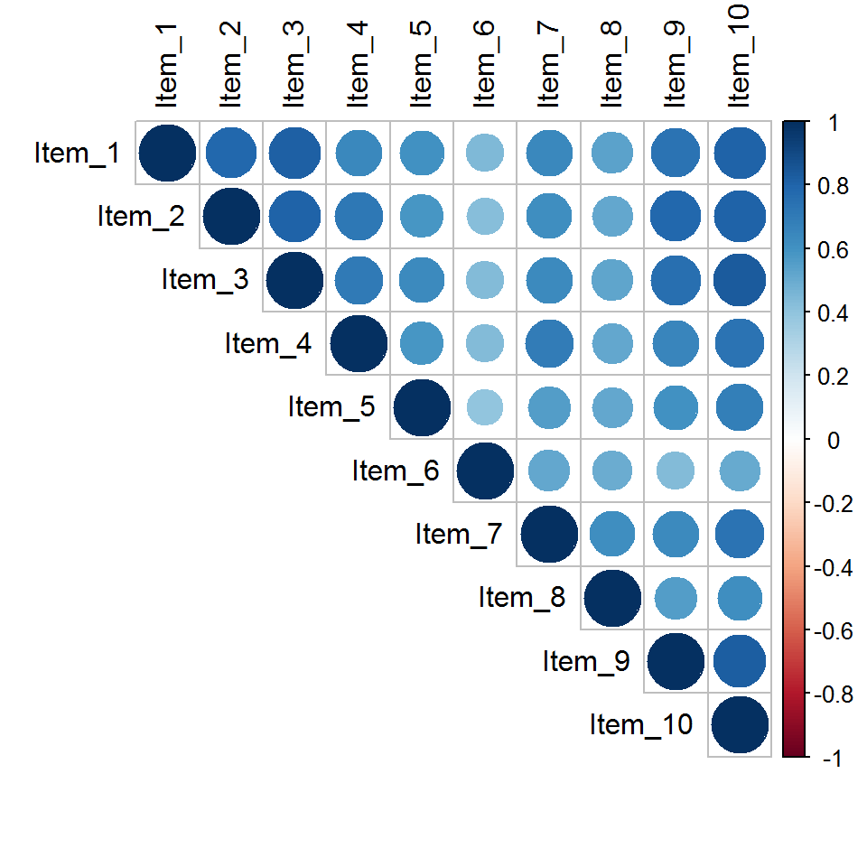

```r
corrplot(correlacion, type = "upper", order = "original",
         tl.col = "black")
```

Miramos las correlaciones excluyendo el item 10, que representa la valoración global del profesor la cual usaremos como variable dependiente en el ejercicio empírico

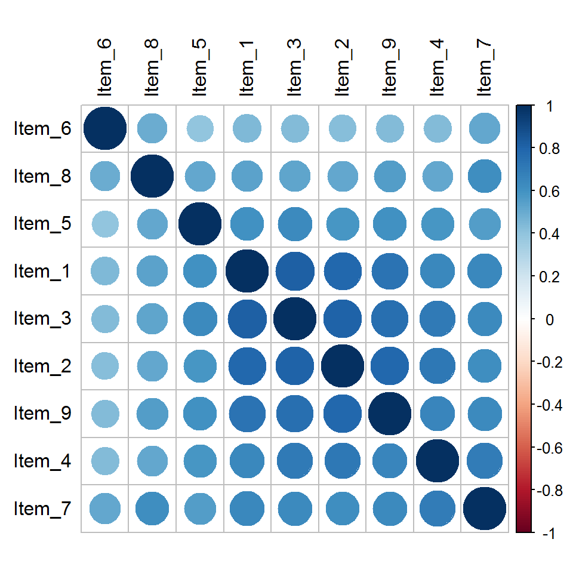

```r
valoraciones.02 <- valoraciones.01[,1:ncol(valoraciones.01)-1]
correlacion2 <- cor(valoraciones.02)
corrplot(correlacion2,  order = "hclust",
         tl.col = "black")
```

La matriz de correlaciones pareciera indicar la existencia de un grupo diferenciado de items o clusters compuesto por los items 1,2,3 y 9.

Observamos los diagramas de cajas e histogramas de los items de valoración

```r
valoraciones.01.flat <- melt(valoraciones.01)
```

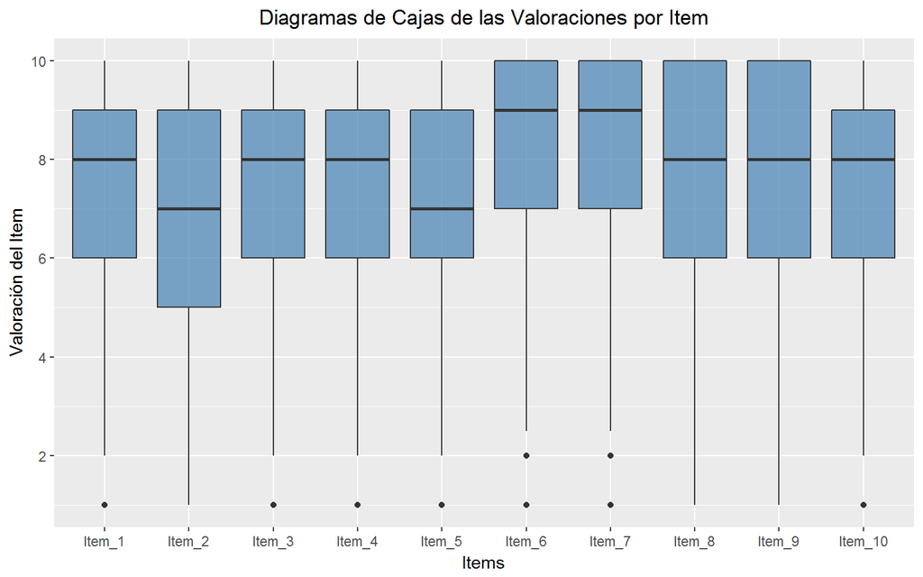

```r
p <- ggplot(valoraciones.01.flat)
p <- p + aes(x=variable, y = value) + geom_boxplot(fill='steelblue', alpha = 0.7)
p <- p + scale_y_continuous(name = "Valoración del Item", breaks = seq(0, 10, 2)) +
  scale_x_discrete(name= "Items")
p <- p + ggtitle("Diagramas de Cajas de las Valoraciones por Item") +
  theme(plot.title = element_text(hjust = 0.5)) #Esto es para centrar el título
p
```

Verificamos si este comportamiento es similar a través de las distintas divisiones

```r
encuesta.01 <- cbind(encuesta$Division,valoraciones.01)
colnames(encuesta.01)[1] <- 'Division'
```

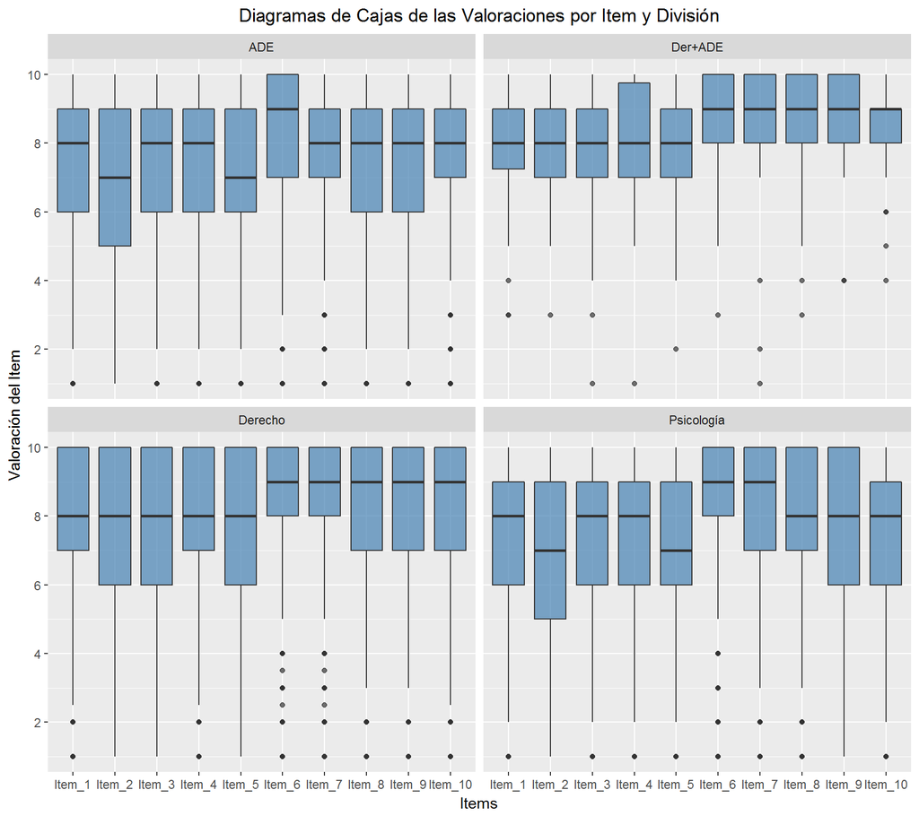

```r
encuesta.01.flat <- melt(encuesta.01, id.vars = 'Division')
p1 <- ggplot(encuesta.01.flat)
p1 <- p1 + aes(x=variable, y = value) + geom_boxplot(fill='steelblue', alpha = 0.7)
p1 <- p1 + scale_y_continuous(name = "Valoración del Item", breaks = seq(0, 10, 2)) +
  scale_x_discrete(name= "Items")
p1 <- p1 + facet_wrap(~Division)
p1 <- p1 + ggtitle("Diagramas de Cajas de las Valoraciones por Item y División") +
  theme(plot.title = element_text(hjust = 0.5)) #Esto es para centrar el título
p1
```

En las divisiones de Derecho + ADE y Derecho tenemos 5 items con una mediana de 8 y otros 5 con una mediana de 9, aunque Derecho presenta una mayor dispersión. ADE y Psicología presenta medianas de 7, 8 y 9, en la primera solo hay un item (6) que presenta una mediana de 9 y el segundo dos (6 y 7).

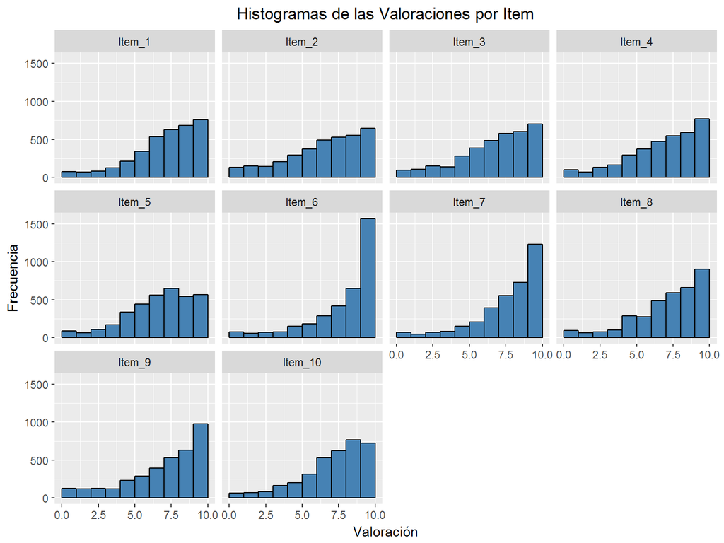

```r
h <- ggplot(valoraciones.01.flat)
h <- h + aes(value)
h <- h + geom_histogram(fill='steelblue', col = 'black', breaks=seq(0, 10, by = 1))
h <- h + facet_wrap(~variable) + ggtitle("Histogramas de las Valoraciones por Item") +
  theme(plot.title = element_text(hjust = 0.5))
h <- h + labs(x="Valoración", y="Frecuencia")
h
```

En los histrogramas destaca el sesgo hacia la derecha que presentan todas las distribuciones de frecuencias. Lo cual es de esperar, ya que la evaluaciones están concentradas en las valoraciones altas y suele haber poca frecuencia de valoraciones muy bajas.

En todos los casos la calificación más frecuente es la máxima (10), excepto en el item 5 (8) y el 10 que representa la valoración global del profesor (9). El item que mayor valoración presenta con diferencia es el 6 (puntualidad)

```r
encuesta.ade <- subset(encuesta.01, Division == 'ADE')
encuesta.ade.flat <- melt(encuesta.ade)
```

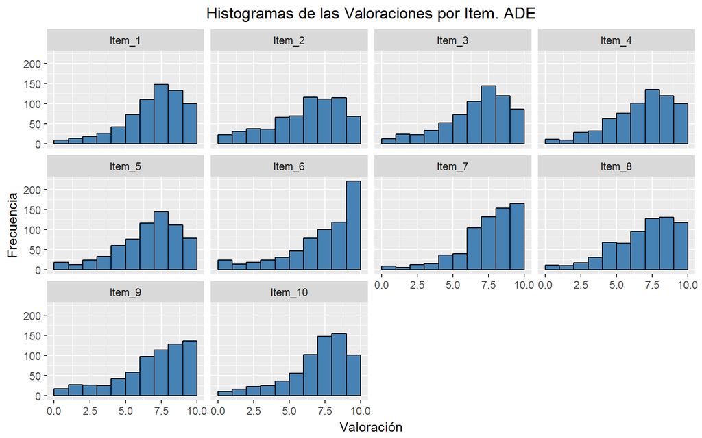

```r
hade <- ggplot(encuesta.ade.flat)
hade <- hade + aes(value)
hade <- hade + geom_histogram(fill='steelblue', col = 'black', breaks=seq(0, 10, by = 1))
hade <- hade + facet_wrap(~variable) + ggtitle("Histogramas de las Valoraciones por Item. ADE") +
  theme(plot.title = element_text(hjust = 0.5)) #Esto es para centrar el título
hade <- hade + labs(x="Valoración", y="Frecuencia")
hade
```

La división de ADE presenta el comportamiento más disímil, solo en 3 de los items (6, 7 y 9) la moda es 10, en el item 2 es 7 y 9 (bimodal), en 4 (1, 3, 4 y 5) es 8 en los dos restantes

```r
encuesta.psi <- subset(encuesta.01, Division == 'Psicología')
encuesta.psi.flat <- melt(encuesta.psi)
```

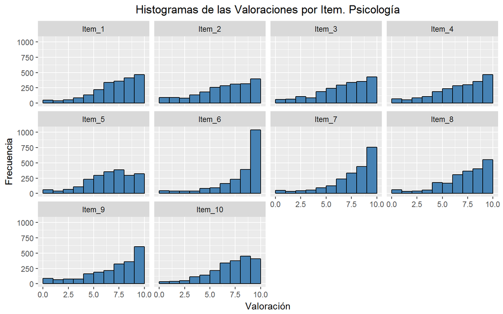

```r
hpsi <- ggplot(encuesta.psi.flat)
hpsi <- hpsi + aes(value)
hpsi <- hpsi + geom_histogram(fill='steelblue', col = 'black', breaks=seq(0, 10, by = 1))
hpsi <- hpsi + facet_wrap(~variable) + ggtitle("Histogramas de las Valoraciones por Item. Psicología") +
  theme(plot.title = element_text(hjust = 0.5)) #Esto es para centrar el título
hpsi <- hpsi + labs(x="Valoración", y="Frecuencia")
hpsi
```

La división de Psicología presenta un comportamiento bastante similar al agregado. Hay que recordar que esta división representa el 61% de las observaciones.

```r
encuesta.der <- subset(encuesta.01, Division == 'Derecho')
encuesta.der.flat <- melt(encuesta.der)
```

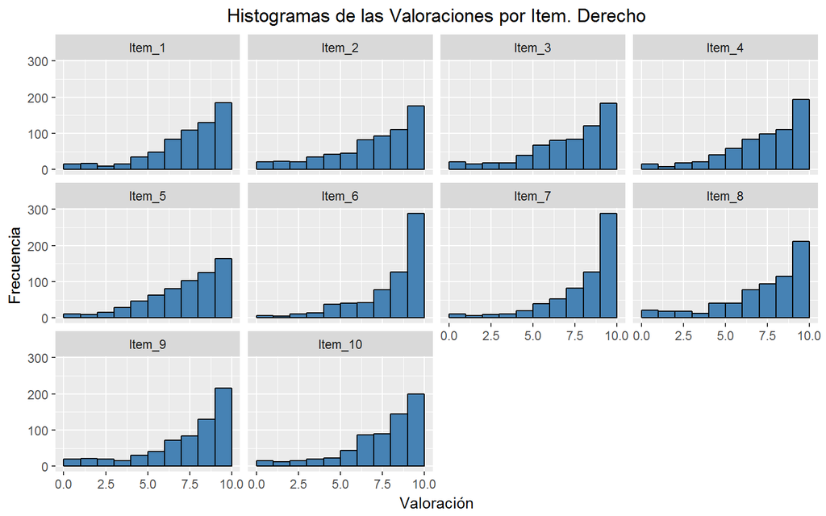

```r
hder <- ggplot(encuesta.der.flat)
hder <- hder + aes(value)
hder <- hder + geom_histogram(fill='steelblue', col = 'black', breaks=seq(0, 10, by = 1))
hder <- hder + facet_wrap(~variable) + ggtitle("Histogramas de las Valoraciones por Item. Derecho") +
  theme(plot.title = element_text(hjust = 0.5))
hder <- hder + labs(x="Valoración", y="Frecuencia")
hder
```

De la división de Derecho destaca que la moda de todos los items es 10

```r
encuesta.derad <- subset(encuesta.01, Division == 'Der+ADE')
encuesta.derad.flat <- melt(encuesta.derad)
```

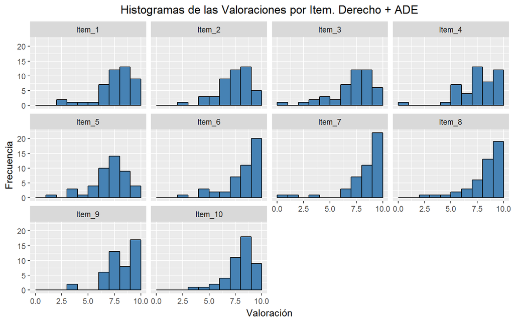

```r
hderad <- ggplot(encuesta.derad.flat)
hderad <- hderad + aes(value)
hderad <- hderad + geom_histogram(fill='steelblue', col = 'black', breaks=seq(0, 10, by = 1))
hderad <- hderad + facet_wrap(~variable) + ggtitle("Histogramas de las Valoraciones por Item. Derecho + ADE") +
  theme(plot.title = element_text(hjust = 0.5))
hderad <- hderad + labs(x="Valoración", y="Frecuencia")
hderad
```

La distribución de calificaciones de Derecho + ADE presenta diferencias con las anteriores, que podrían explicarse por el hecho que solo hay un grupo y por ende muy pocos datos en relación al resto de divisiones.

Observamos algunos estadísticos básicos de la valoración global por división

```r
encuesta.02 <- group_by(encuesta.01, Division) %>%
                summarise(Media = mean(Item_10),
                          Mediana = median(Item_10),
                          Desviacion = sd(Item_10),
                          Obsevaciones = n())
kable(as.matrix(encuesta.02), digits = 2, align = c('c', 'c', 'c', 'c'),
      caption = 'Valoración Global por División')
```

Valoración Global por División

| Division | Media | Mediana | Desviacion | Obsevaciones |
| --- | --- | --- | --- | --- |
| ADE | 7.473373 | 8 | 2.152697 | 676 |
| Der+ADE | 8.456522 | 9 | 1.345057 | 46 |
| Derecho | 7.954475 | 9 | 2.252049 | 648 |
| Psicología | 7.479880 | 8 | 2.181267 | 2162 |

Las divisiones de ADE y Psicología se encuentran levemente por debajo de la media, mientras que las de Derecho y Derecho+ADE por encima.

# 4 Análisis factorial

El análisis factorial se puede interpretar como una técnica de reducción de dimensionalidad, pero a diferencia del análisis de componentes principales, el primero asume un proceso generador de datos como explicaremos más adelante, no explica toda la varianza de la muestra y además se concentra no en la varianza sino en las covarianzas entre las variables.

En el presente trabajo asumimos que hay grupos de items que se mueven en la misma dirección debido a que evalúan una determinada aptitud o característica común. Lo anterior nos presenta un par de retos. Primero, debido a la alta correlación entre los items arriba expuesta cualquier ejercicio de regresión genera estimadores no eficientes, y por ende, los contrastes de hipótesis individual y conjunto de los parámetros no son informativos. Segundo, si consideramos que existen factores comunes no observables que afectan de manera separada a grupos de items generando dicha correlación, podríamos emplear dichos factores comunes en lugar de todos los items.

Debido a lo anterior realizamos un análisis factorial que nos permita extraer las variables no observables que afectan a la covarianza entre items.

Como se menciona arriba el análisis factorial asume un proceso generador de datos, el cual establece que las variables en estudio dependen linealmente de un conjunto de variables no observables o *latentes*. Consideramos un vector de variables observables $x =(x_1,x_2, \ldots , x_p)$ que se encuentran relacionados linealmente con un número de variables latentes $f_1,f_2, \ldots, f_k$ donde $k<p$ de la siguiente forma:

$$\begin{eqnarray}
x_1 & = \mu_1 + \lambda_{11}f_1 + \ldots + \lambda_{1k}f_k + u_1\\
\vdots & \vdots \\
x_p & = \mu_p + \lambda_{p1}f_1 + \ldots + \lambda_{pk}f_k + u_p
\end{eqnarray}$$

representado de modo matricial

$$\mathbf{x} = \mathbf{\mu} + \Lambda\mathbf{f} + \mathbf{u}$$

donde $\mathbf{f}$ es un vector $(k \times 1)$ de variables *latentes* no observadas que llamaremos factores. $\Lambda$ una matriz $(p \times k)$ de parámetros desconocidos y $\mathbf{u}$ un vector $(p \times 1)$ de perturbaciones.

Las expresiones anteriores establecen que los valores observados (en nuestro caso los items de valoración) dependen linealmente de los factores y una perturbación aleatoria que resume el efecto de todas las variables distintas a los factores sobre los valores observados. Como es usual, se asume que los errores son independientes entre si y de los factores, y siguen una distribución normal de media cero y varianza constante, $N_p(0,\Psi)$. Lo anterior implica que $\Psi$ es una matriz diagonal.

Los elementos de la matriz $\Lambda$ se denominan *cargas* y representan como los factores afectan a las variables observadas. Nos diran por ejemplo si el factor “docencia” ejerece un efecto importantes o no sobre el item 8 por ejemplo. Se asume que las cargas son variables aleatorias que siguen una distribución normal multiviarante estandarizada $N_k(0,\mathbf{I})$.

Dado que $\mathbf{x}$ es una suma de variables normales tiene distribución normal. Asimismo ya que la media de los factores y la perturbación es cero la media de $\mathbf{x}$ es $\mathbf{\mu}$, resumiendo $\mathbf{x} \thicksim N_p(\mathbf{\mu},\mathbf{V})$

A partir de lo anterior podemos calcular la varianza de la variable $x_i$:

$$\begin{align}
& Var(x_i) = \lambda_{i1}^2Var(f_1)+ \ldots + \lambda_{ik}^2Var(f_k)+Var(u_i) \\
& Var(x_i) = \sum_{j=1}^{k}\lambda_{ij}^2 + \psi_i
\end{align}$$

La varianza de cada variable observada se puede descomponer en dos partes. Por un lado, $\sum_{j=1}^{k}\lambda_{ij}^2$ se denomina comunalidad y representa aquella parte de la $x_i$ explicada por los factores y por ende la varianza compartida con el resto de las variables. Por su parte $\psi_i$ es la varianza específica y por lo tanto no compartida con las demás variables.

Podemos obtener la matriz de covarianzas entre las observaciones partiendo de su definición $E[(\mathbf{x}-\mathbf{\mu})(\mathbf{x}-\mathbf{\mu})']$, donde $\mathbf{x}-\mathbf{\mu} = \Lambda\mathbf{f} + \mathbf{u}$

$$\begin{align}
E[(\mathbf{x}-\mathbf{\mu})(\mathbf{x}-\mathbf{\mu})'] =& E[(\Lambda\mathbf{f} + \mathbf{u})(\Lambda\mathbf{f} + \mathbf{u})'] \\
E[(\mathbf{x}-\mathbf{\mu})(\mathbf{x}-\mathbf{\mu})'] =& \Lambda E[\mathbf{f}\mathbf{f'}']\Lambda'+
\Lambda E[\mathbf{f}\mathbf{u}']+\Lambda E[\mathbf{f'}\mathbf{u}]+E[\mathbf{u}\mathbf{u}']\\
E[(\mathbf{x}-\mathbf{\mu})(\mathbf{x}-\mathbf{\mu})'] =& \Lambda \Lambda'+E[\mathbf{u}\mathbf{u}']\\
E[(\mathbf{x}-\mathbf{\mu})(\mathbf{x}-\mathbf{\mu})'] =& \Lambda \Lambda'+\mathbf{\psi}
\end{align}$$
donde $\Lambda \Lambda'$ y $\mathbf{\psi}$ representan la comunalidad y varianza específica descrita arriba.

El problema que se plantea en el modelo factorial es estimar los parámetros $\hat{\Lambda}$ y $\hat{\mathbf{\psi}}$ a partir de la matriz de covarianzas *muestral*, de modo que esta sea lo más próxima posible a la matriz de covarianzas teórica $\Lambda \Lambda'+\mathbf{\psi}$.

Dicha estimación suele hacerse o por el método de los factores principales o por máxima verosimilitud, nosotros emplearemos esta última en este ejercicio.

Por último mencionamos el tópico de las rotaciones, el cual emplearemos posteriormente. En el modelo factorial las cargas no son únicas, es decir, para el mismo conjunto de observaciones distintos valores de los parámetros podrían representar la misma relación entre factores (no observables) y las $\mathbf{x}$.

Formalmente, si multiplicamos una matriz ortogonal $M$ por la matriz de pesos de la siguiente forma:
$$\mathbf{x} = \mathbf{\mu} + (\Lambda M)(M'\mathbf{f}) + \mathbf{u}$$
Este modelo es indistinguible del anterior si escribimos los factores como $\mathbf{f^*=M'\mathbf{f}}$ y la matriz de cargas $\Lambda^*=\Lambda M$:
$$\mathbf{x} = \mathbf{\mu} + \Lambda^* \mathbf{f}^* + \mathbf{u}$$
La matriz de covarianzas de este modelo “nuevo” siguiendo la expresión derivada anteriormente sería:
$$E[(\mathbf{x}-\mathbf{\mu})(\mathbf{x}-\mathbf{\mu})'] = \Lambda^*\Lambda^{*'} +\mathbf{\psi} = (\Lambda M) (\Lambda M)'+\mathbf{\psi}$$

Dado que $MM'=I$, la matriz de covarianzas sería $\Lambda \Lambda'+\mathbf{\psi}$, la misma que la de las observaciones originales. Formalmente se dice que el modelo está *indeterminado ante rotaciones*.

No obstante, lo que pareciera ser una desventaja en realidad es una propiedad útil en la práctica. Por ejemplo en nuestro caso hemos postulado la existencia de un número determinado de factores, lo cual implica unas cargas altas y otras cercanas a cero de modo que de manera clara unos factores afectan a unas variables y a otras no. Pero este no suele ser el primer resultado que se obtiene al estimar los factores, ya que se podrían obtener factores complicados de entender al afectar de manera similar a todas las variables.

Cuando esto ocurre podemos “rotar” los factores de manera que obtengamos una interpretación más razonable y sea equivalente al modelo original. Las rotaciones que se emplean suelen generar cargas muy altas y otras muy pequeñas, de modo que sea más fácil la interpretación y/o más cercanas a nuestro a priori.

## 4.1 Hipótesis del número de factores

A continuación mostramos como elaboramos nuestra hipótesis de partida, la existencia de dos factores que engloban los aspectos docentes por un lado, y aquellos relativos a la relación entre el profesor y el alumno respectivamente.

Mostramos las preguntas que se realizan en la encuesta

```r
items.enc <- read_excel("~/KSchool/TFM/items.xlsx", col_names = FALSE)
num.preg <- seq(10)
items.enc <-  cbind(num.preg,items.enc)
colnames(items.enc) <- c('Número','Preguntas')
kable(items.enc, format = 'html') %>%
  kable_styling(bootstrap_options = c("striped", "hover"))
```

| Número | Preguntas |
| --- | --- |
| 1 | El profesor/a explica con orden y claridad. |
| 2 | El profesor/a logra mantener mi atención en clase. |
| 3 | La forma de dar clase y la metodología empleada por el profesor/a facilitan la comprensión de los contenidos de la asignatura. |
| 4 | El profesor/a fomenta la participación en clase y anima a los alumnos/as a plantear preguntas y dudas en clase. |
| 5 | Los criterios de evaluación establecidos permiten que el profesor/a se forme una visión realista y detallada del nivel de aprendizaje alcanzado por cada alumno/a. |
| 6 | El profesor/a acude a clase puntualmente. |
| 7 | El profesor/a atiende adecuadamente las dudas y/o preguntas que los alumnos le planteamos en clase. |
| 8 | Cuando yo o alguno de mis compañeros/as, envía un correo electrónico al profesor/a, o se ha dirigido al profesor/a a través del campus virtual, el profesor/a ha respondido de forma rápida y eficaz. |
| 9 | Resulta de interés asistir a sus clases para preparar adecuadamente la asignatura. |
| 10 | Evalúa del 1 al 10 tu grado de satisfacción global con respecto al profesor/a. |

Se observa que los 5 primeros items y el 9, parecieran tener más relación con la actividad docente como tal, mientras que los que van del 6 al 8 con la interacción entre el docente y el alumno.

A partir de esto postulamos la potencial existencia de dos factores: *docencia* y *relación alumno-profesor*.

## 4.2 Contrastes previos a la extracción de factores

El análisis factorial tiene sentido en la medida que las variables en estudio se encuentren altamente correladadas, los tests previos realizan contrastes que permiten contrastar la hipótesis de alta o baja correlación entre las variables, en nuestro caso los items de la encuesta.

### 4.2.1 Test de Barlett

Asumiendo el caso extremo de ninguna relación entre los items, la matriz de correlaciones sería una matriz identidad. Es decir, los elementos fuera de la diagonal que representan las correlaciones entre los items serían iguales a cero, y la diagonal como es habitual igual a uno. En este caso el determinante de la matriz es igual a uno

Partiendo de esto el test de Barlett toma como hipótesis nula que el determinante de la matriz de correlaciones es igual a uno y como alternativa que el mismo es distinto de uno. Bajo la hipótesis nula el estadístico de contraste sigue una distribución chi-cuadrado.

```r
BT <- bartlett.test(valoraciones.02)
BT$statistic
```

```
## Bartlett's K-squared
##             204.2618
```

```r
BT$p.value
```

```
## [1] 8.076886e-40
```

El valor del estadístico es alto y el p-valor cercano a cero, por lo que se rechaza la hipótesis nula de ausencia de correlación entre los items con un nivel de significatividad del 1%

### 4.2.2 Test KMO

El siguiente contraste es el test KMO (Kaiser, Meyer y Olkin) o de adecuación muestral, el cual parte de la idea de que si un cojunto de variables se encuentran altamente relacionadas entre si, sus coeficientes de correlación serán altos mientras que sus coeficientes de correlación parcial (relación entre pares de variables sin tomar en cuenta el efecto del resto de las variables) serán bajos. De ser esto así, los factores comunes entre las variables serán de importancia

Algebraicamente se calcula si la siguiente expresión

$$\frac{\sum\limits_{j}\sum\limits_{h\neq j}r_{jh}^2}{\sum\limits_{j}\sum\limits_{h\neq j}r_{jh}^2 + \sum\limits_{j}\sum\limits_{h\neq j}a_{jh}^2}$$
donde $r_{jh}$ es el coeficiente de correlación entre las variables $x_j$ y $x_h$. $a_{jh}$ es el coeficiente de correlación parcial entre las variables $x_j$ y $x_h$.

Como se puede observar, a medida que es menor el valor del coeficiente de correlación parcial más se acerca a la unidad la expresión. Valores cercanos a uno del KMO indican un alto grado de asociación de las variables debido a factores comunes.

En la literatura varios autores señalan distintas *escalas* de la adecuación de los datos a un estudio factorial según el valor del KMO. Enumeramos la propuesta por Kaiser y citada en la documentación del paquete [REdaS](https://cran.r-project.org/web/packages/REdaS/REdaS.pdf): maravilloso si KMO ≥ 0.9, mieritorio si 0.9 > KMO ≥ 0.8 <; mediano para 0.8 > KMO ≥ 0.7; mediocre para 0.7 > KMO ≥ 0.6; miserable si 0.6 > KMO ≥ 0.5 e inaceptable para KMO < 0.5.

```r
KMO.T <- KMOS(valoraciones.02, use= "pairwise.complete.obs")
KMO.T$KMO
```

```
## [1] 0.9337983
```

El valor del test KMO es de 0.9337983, por lo que nuestra muestra puede ser calificada de adecuada para un análisis factorial

## 4.3 Determinación de los factores

Procedemos a estimar los factores con el uso de la función `factanal` la cual emplea el método de máxima verosimilitud.

Dada la estructura de las preguntas de la encuentas, partimos de la hipótesis de que existen dos factores.

```r
set.seed(123)

fa.valoraciones1 <- factanal(valoraciones.02, factors = 2, rotation = "none", scores = "regression")
fa.valoraciones1$loadings
```

```
##
## Loadings:
##        Factor1 Factor2
## Item_1  0.871  -0.114
## Item_2  0.882  -0.176
## Item_3  0.896  -0.155
## Item_4  0.800   0.119
## Item_5  0.704
## Item_6  0.537   0.298
## Item_7  0.779   0.377
## Item_8  0.649   0.315
## Item_9  0.851
##
##                Factor1 Factor2
## SS loadings      5.517   0.420
## Proportion Var   0.613   0.047
## Cumulative Var   0.613   0.660
```

```r
fa.valoraciones1$uniquenesses
```

```
##    Item_1    Item_2    Item_3    Item_4    Item_5    Item_6    Item_7
## 0.2285090 0.1914755 0.1728763 0.3464977 0.4992957 0.6222856 0.2507069
##    Item_8    Item_9
## 0.4793332 0.2716534
```

```r
fa.valoraciones1$STATISTIC
```

```
## objective
##  496.0537
```

```r
fa.valoraciones1$PVAL
```

```
##    objective
## 3.758585e-93
```

```r
factores1 <- fa.valoraciones1$scores
```

EL primer factor tiene una alta carga en los items 1,2,3 y 9, mientras que el factor 2 no pareciera tener cargas relevantes en ningún item.

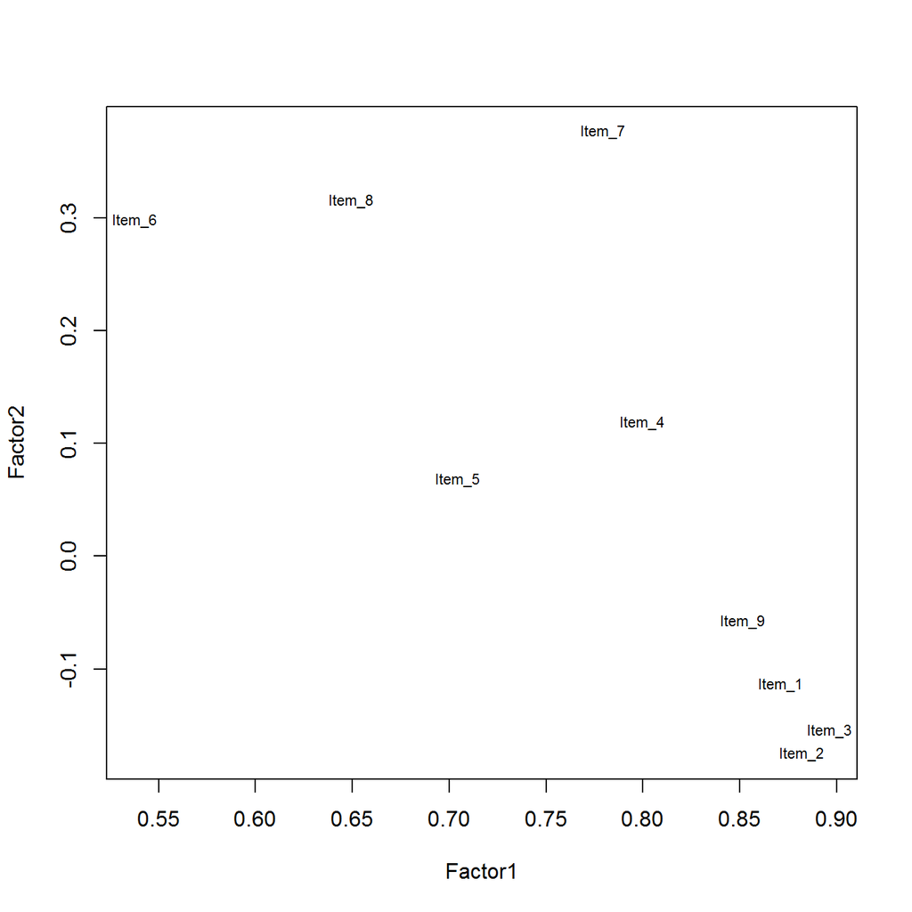

```r
cargas1 <- fa.valoraciones1$loadings[,1:2]
plot(cargas1,type="n")
text(cargas1,labels=names(valoraciones.02),cex=.7)
```

Aplicamos una rotación ortogonal empleando el método Varimax, el cual maximiza la varianza de las cargas al cuadrado de cada factor, de este modo hace que algunas de las cargas sean lo más grandes posibles mientras que el resto sean lo más pequeñas. Así obtenemos cargas muy altas en algunos items y casi nulas en otros.

```r
fa.valoraciones2 <- factanal(valoraciones.02, factors = 2, rotation = "varimax", scores = "regression")
fa.valoraciones2$loadings
```

```
##
## Loadings:
##        Factor1 Factor2
## Item_1 0.770   0.422
## Item_2 0.815   0.379
## Item_3 0.815   0.404
## Item_4 0.576   0.568
## Item_5 0.529   0.470
## Item_6 0.258   0.558
## Item_7 0.407   0.764
## Item_8 0.338   0.638
## Item_9 0.721   0.456
##
##                Factor1 Factor2
## SS loadings      3.399   2.538
## Proportion Var   0.378   0.282
## Cumulative Var   0.378   0.660
```

```r
fa.valoraciones2$uniquenesses
```

```
##    Item_1    Item_2    Item_3    Item_4    Item_5    Item_6    Item_7
## 0.2285090 0.1914755 0.1728763 0.3464977 0.4992957 0.6222856 0.2507069
##    Item_8    Item_9
## 0.4793332 0.2716534
```

```r
fa.valoraciones2$STATISTIC
```

```
## objective
##  496.0537
```

```r
fa.valoraciones2$PVAL
```

```
##    objective
## 3.758585e-93
```

```r
factores2 <- fa.valoraciones2$scores
```

Ahora el factor 1 sigue teniendo cargas altas en los items 1, 2, 3 y 9 aunque el peso del item 1 ha disminuido. Por su parte el factor 2 ha incrementado basante sus cargas en ciertos items, retiene el item 6 y presenta saturaciones altas en los items 7 y 8.

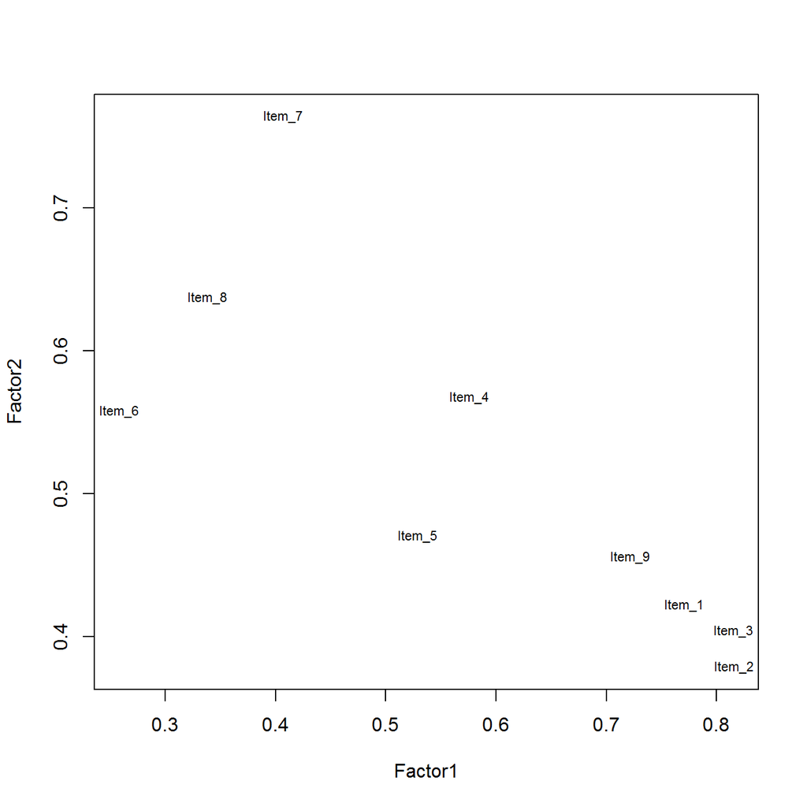

```r
cargas2 <- fa.valoraciones2$loadings[,1:2]
plot(cargas2,type="n")
text(cargas2,labels=names(valoraciones.02),cex=.7)
```

Se empieza a visualizar nuestra hipótesis de partida de dos factores que representen los aspectos docentes de la asignatura (items 1, 2, 3 y 9) y la relación alumno-profesor (items 6, 7 y 8). Podríamos considerar el item 4 como una mezcla de ambos, mientras que no queda claro donde incluir el item 5 aunque presenta un sesgo hacia la opción docente.

Ahora realizamos una rotación oblicua, la cual a diferencia de la ortogonal permite cierta correlación entre los factores. Se emplea el método Promax

```r
fa.valoraciones3 <- factanal(valoraciones.02, factors = 2, rotation = "promax", scores = "regression")
fa.valoraciones3$loadings
```

```
##
## Loadings:
##        Factor1 Factor2
## Item_1  0.785   0.114
## Item_2  0.886
## Item_3  0.865
## Item_4  0.387   0.466
## Item_5  0.396   0.351
## Item_6          0.667
## Item_7          0.877
## Item_8          0.733
## Item_9  0.688   0.197
##
##                Factor1 Factor2
## SS loadings      2.932   2.146
## Proportion Var   0.326   0.238
## Cumulative Var   0.326   0.564
```

```r
fa.valoraciones3$uniquenesses
```

```
##    Item_1    Item_2    Item_3    Item_4    Item_5    Item_6    Item_7
## 0.2285090 0.1914755 0.1728763 0.3464977 0.4992957 0.6222856 0.2507069
##    Item_8    Item_9
## 0.4793332 0.2716534
```

```r
fa.valoraciones3$STATISTIC
```

```
## objective
##  496.0537
```

```r
fa.valoraciones3$PVAL
```

```
##    objective
## 3.758585e-93
```

```r
factores3 <- fa.valoraciones3$scores
```

Como era de esperarse ahora tenemos saturaciones más claras, en este caso refuerzan las conclusiones de la rotación ortogonal.

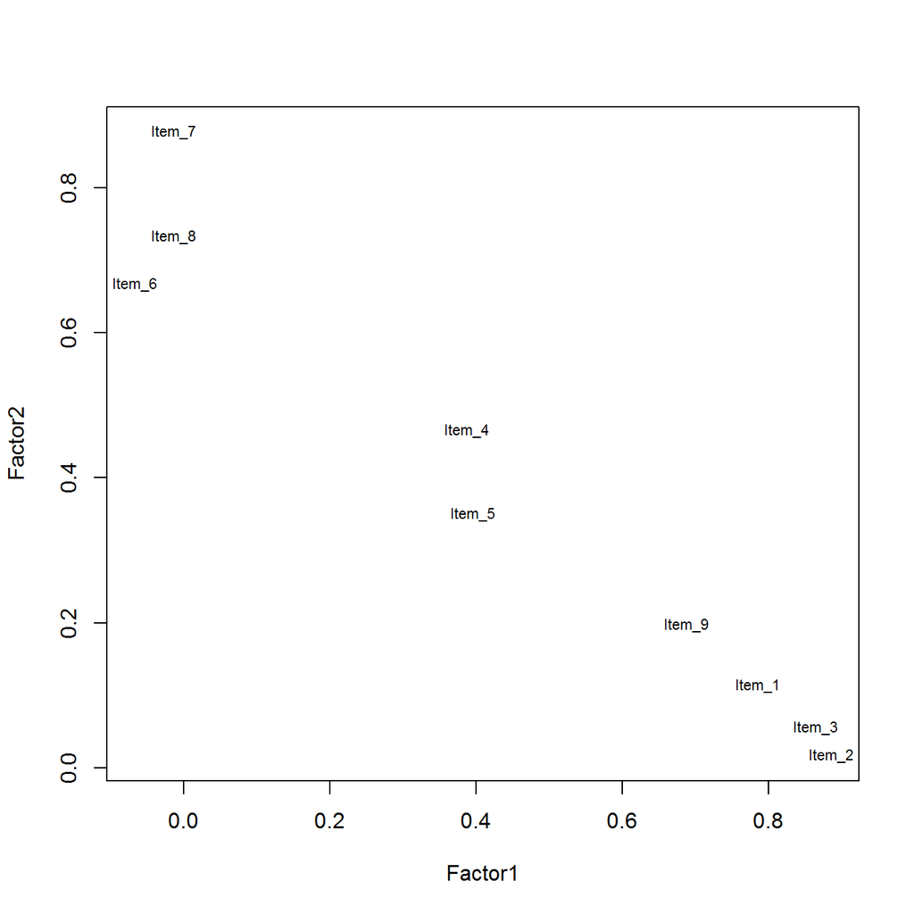

```r
cargas3 <- fa.valoraciones3$loadings[,1:2]
plot(cargas3,type="n")
text(cargas3,labels=names(valoraciones.02),cex=.7)
```

En el gráfico se observa una separación más clara entre los items que corresponden a cada factor, los correspondientes a la labor docente y a la relación profesor alumno.

Finalmente analizamos el gráfico de sedimentación para verificar el número de factores a tomar

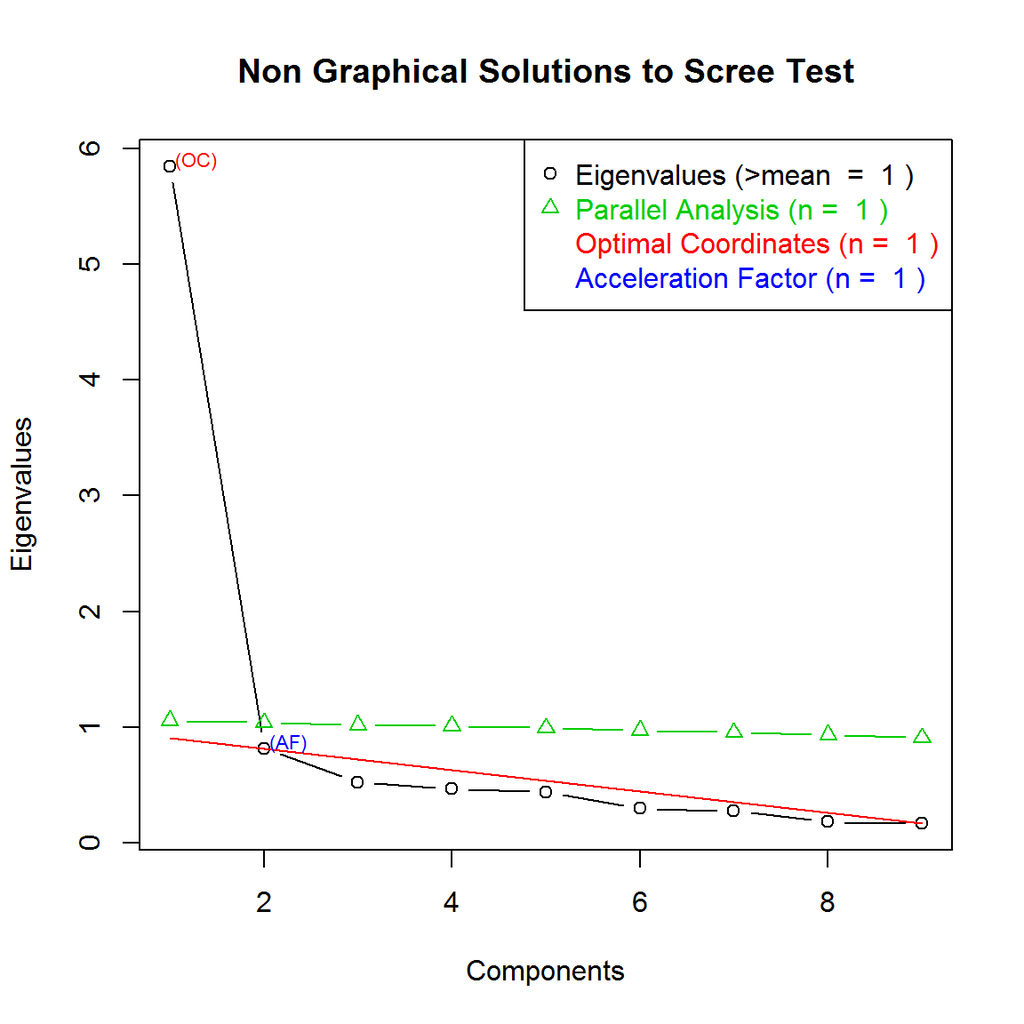

```r
ev <- eigen(cor(valoraciones.02))
ap <- parallel(subject=nrow(valoraciones.02),var=ncol(valoraciones.02), rep=100, cent=.05)
nS <- nScree(x=ev$values, aparallel=ap$eigen$qevpea)
plotnScree(nS)
```

Observando la tasa a la cual deja de caer la varianza explicada, pareciera que dos factores es una buena alternativa, a pesar que el segundo valor propio se encuentra debajo de uno.

Decidimos mantener dos factores debido a su facilidad de interpretación y asociación con los factores no observables que se han postulado al inicio del análisis.

# 5 Regresión Logística

En esta sección se construye una regresión logística con el objeto de analizar el efecto de una serie de variables sobre la valoración de una asignatura.

La variable dependiente (respuesta, target) es la valoración de una asignatura. Las variables independientes o regresores son:

- Los factores obtenidos en el apartado anterior, y los cuales resumen las características latentes evaluadas en la encuesta, *docencia* y *relación alumno-profesor*
- Características individuales de los profesores:
  - Edad
  - Sexo
  - Tipo de asignatura (cuantitativa o no)
  - Categoría (licenciado, doctor, titular o catedrático)
  - Tener o no un cargo administrativo dentro de la universidad
  - Estar en posesión o no de una acreditación de la ANECA

Los factores y la edad son variables continuas, el tipo de asignatura, cargo administrativo y la acreditación son binarias 0-1 y la categoría es una variable categórica con 4 niveles del 1 al 4.

Las variables se encuentran codificadas del siguiente modo:

- Sexo: 1 si es hombre y 0 si es mujer
- Cuantitativa: 1 si el profesor imparte alguna asignatura de tipo cuantitativo y 0 en caso contrario
- Categoria: 1 licenciado, 2 doctor, 3 titular y 4 catedrático
- Tareas de gestión: 1 si se dedica a ello y 0 si no lo hace
- Acreditación: toma el valor 1 si el individuo tiene algún tipo de acreditación y 0 en caso contrario (los funcionarios están incluidos como acreditados)

Cargamos los datos e inspeccionamos los mismos

```r
datos_profesores <- read_excel("~/KSchool/TFM/datos_profesores_v2.xlsx")

dim(datos_profesores)
```

```
## [1] 95  7
```

```r
head(datos_profesores)
```

```
## # A tibble: 6 × 7
##   codigo  edad  sexo cuantitativa categoria `tareas organizativas`
##    <dbl> <dbl> <dbl>        <dbl>     <dbl>                  <dbl>
## 1      1    43     1            1         1                      0
## 2      2    40     0            1         2                      1
## 3      3    61     0            0         2                      0
## 4      4    58     0            0         2                      1
## 5      6    40     1            1         2                      1
## 6      7    48     0            0         1                      0
## # ... with 1 more variables: `ANECA/ACAP` <dbl>
```

```r
tail(datos_profesores)
```

```
## # A tibble: 6 × 7
##   codigo  edad  sexo cuantitativa categoria `tareas organizativas`
##    <dbl> <dbl> <dbl>        <dbl>     <dbl>                  <dbl>
## 1    439    65     1            0         1                      0
## 2    440    32     0            0         1                      0
## 3    452    34     0            0         2                      0
## 4    447    41     0            0         1                      0
## 5    448    32     0            0         1                      0
## 6     NA    NA    NA           NA        NA                     NA
## # ... with 1 more variables: `ANECA/ACAP` <dbl>
```

```r
summary(datos_profesores)
```

```
##      codigo            edad            sexo         cuantitativa
##  Min.   :  1.00   Min.   :28.00   Min.   :0.0000   Min.   :0.0000
##  1st Qu.: 27.25   1st Qu.:41.25   1st Qu.:0.0000   1st Qu.:0.0000
##  Median :226.50   Median :48.50   Median :1.0000   Median :0.0000
##  Mean   :245.34   Mean   :50.21   Mean   :0.5426   Mean   :0.1064
##  3rd Qu.:417.75   3rd Qu.:58.00   3rd Qu.:1.0000   3rd Qu.:0.0000
##  Max.   :452.00   Max.   :90.00   Max.   :1.0000   Max.   :1.0000
##  NA's   :1        NA's   :1       NA's   :1        NA's   :1
##    categoria     tareas organizativas   ANECA/ACAP
##  Min.   :1.000   Min.   :0.0000       Min.   :0.000
##  1st Qu.:1.000   1st Qu.:0.0000       1st Qu.:0.000
##  Median :2.000   Median :0.0000       Median :0.000
##  Mean   :1.649   Mean   :0.1915       Mean   :0.266
##  3rd Qu.:2.000   3rd Qu.:0.0000       3rd Qu.:1.000
##  Max.   :4.000   Max.   :1.0000       Max.   :1.000
##  NA's   :1       NA's   :1            NA's   :1
```

Eliminos las filas con NA’s. En nuestro caso específico es solo la última fila

```r
datos_profesores <- na.omit(datos_profesores)
```

Convertimos la tabla en data frame

```r
datos_profesores.01 <- as.data.frame(datos_profesores)
```

Cambiamos los nombres de las dos últimas columnas

```r
colnames(datos_profesores.01)[6:ncol(datos_profesores.01)] <- c('Gestion','Acreditacion')
```

Hacemos que los códigos sean los índices del data frame

```r
rownames(datos_profesores.01) <- datos_profesores.01$codigo
datos_profesores.01[,1] <- NULL
```

Añadimos los factores estimados en el apartado anterior

```r
encuesta.fac <- cbind(encuesta, factores3)
```

Asimismo eliminamos los items de respuesta, ya que (parte de) dicha información está resumida en los factores

```r
encuesta.fac01 <- encuesta.fac[,-c(6:14)]
```

También eliminamos la información administrativa distinta del profesor

```r
encuesta.fac01 <- encuesta.fac01[,-c(1:4)]
```

En el siguiente bucle añadimos las columnas de características de los docentes al data frame de las encuestas

```r
encuesta.logit <- as.data.frame(encuesta.fac01)
encuesta.logit.01 <- list()

for(i in 1:nrow(encuesta.logit)){
  encuesta.logit.01[[i]] <- cbind(encuesta.logit[i,],
                                  datos_profesores.01[as.character(encuesta.logit[i,'Profesor']),])
}
```

“Juntamos” las elementos de las filas como filas y convertimos en un data frame

```r
encuesta.logit.temp <- do.call('rbind',encuesta.logit.01)
encuesta.logit.temp1 <- as.data.frame(encuesta.logit.temp)
```

Debido al tipo de contrato hay profesores que no aparecen en la base de datos del centro, al no tener sus características pero si estar en las encuestas, las columnas de características aparece como NA’s al juntar las columnas.

Eliminamos estos registros

```r
encuesta.logit.02 <- na.omit(encuesta.logit.temp1)
dim(encuesta.logit.temp1)
```

```
## [1] 3532   10
```

```r
dim(encuesta.logit.02)
```

```
## [1] 3292   10
```

Finalmente, eliminamos la columna de profesores, ya que la hemos empleado solo para añadir las características de los mismos

```r
encuesta.logit.03 <- encuesta.logit.02[,-c(1)]
```

Procedemos a convertir la variable dependiente `Item_10` en binaria. Se sigue un trabajo anterior hecho en el centro y se divide la valoración global de la encuesta en *Alta* si la valoración es mayor a 6 y *Baja* en caso contrario

```r
encuesta.logit.03$Target <- 1

for(i in 1:nrow(encuesta.logit.03)){
  if (encuesta.logit.03$Item_10[i] > 6){
    encuesta.logit.03$Target[i] = 1
  }
  else{
    encuesta.logit.03$Target[i] = 0
  }
}
```

Observamos las proporciones

Totales

```r
CrossTable(encuesta.logit.03$Target)
```

```
##
##
##    Cell Contents
## |-------------------------|
## |                       N |
## |         N / Table Total |
## |-------------------------|
##
##
## Total Observations in Table:  3292
##
##
##           |         0 |         1 |
##           |-----------|-----------|
##           |       818 |      2474 |
##           |     0.248 |     0.752 |
##           |-----------|-----------|
##
##
##
##
```

Se observan proporciones algo desblanceadas, 25% de valoraciones bajas y 75% altas

Según categoría

```r
CrossTable(encuesta.logit.03$Target, encuesta.logit.03$categoria,
           prop.r = TRUE, prop.c = FALSE, prop.t = FALSE,
           prop.chisq = FALSE)
```

```
##
##
##    Cell Contents
## |-------------------------|
## |                       N |
## |           N / Row Total |
## |-------------------------|
##
##
## Total Observations in Table:  3292
##
##
##                          | encuesta.logit.03$categoria
## encuesta.logit.03$Target |         1 |         2 |         3 |         4 | Row Total |
## -------------------------|-----------|-----------|-----------|-----------|-----------|
##                        0 |       270 |       510 |        19 |        19 |       818 |
##                          |     0.330 |     0.623 |     0.023 |     0.023 |     0.248 |
## -------------------------|-----------|-----------|-----------|-----------|-----------|
##                        1 |       935 |      1496 |         6 |        37 |      2474 |
##                          |     0.378 |     0.605 |     0.002 |     0.015 |     0.752 |
## -------------------------|-----------|-----------|-----------|-----------|-----------|
##             Column Total |      1205 |      2006 |        25 |        56 |      3292 |
## -------------------------|-----------|-----------|-----------|-----------|-----------|
##
##
```

Según sexo

```r
CrossTable(encuesta.logit.03$Target, encuesta.logit.03$sexo,
           prop.r = TRUE, prop.c = FALSE, prop.t = FALSE,
           prop.chisq = FALSE)
```

```
##
##
##    Cell Contents
## |-------------------------|
## |                       N |
## |           N / Row Total |
## |-------------------------|
##
##
## Total Observations in Table:  3292
##
##
##                          | encuesta.logit.03$sexo
## encuesta.logit.03$Target |         0 |         1 | Row Total |
## -------------------------|-----------|-----------|-----------|
##                        0 |       427 |       391 |       818 |
##                          |     0.522 |     0.478 |     0.248 |
## -------------------------|-----------|-----------|-----------|
##                        1 |      1290 |      1184 |      2474 |
##                          |     0.521 |     0.479 |     0.752 |
## -------------------------|-----------|-----------|-----------|
##             Column Total |      1717 |      1575 |      3292 |
## -------------------------|-----------|-----------|-----------|
##
##
```

Según gestión

```r
CrossTable(encuesta.logit.03$Target, encuesta.logit.03$Gestion,
           prop.r = TRUE, prop.c = FALSE, prop.t = FALSE,
           prop.chisq = FALSE)
```

```
##
##
##    Cell Contents
## |-------------------------|
## |                       N |
## |           N / Row Total |
## |-------------------------|
##
##
## Total Observations in Table:  3292
##
##
##                          | encuesta.logit.03$Gestion
## encuesta.logit.03$Target |         0 |         1 | Row Total |
## -------------------------|-----------|-----------|-----------|
##                        0 |       619 |       199 |       818 |
##                          |     0.757 |     0.243 |     0.248 |
## -------------------------|-----------|-----------|-----------|
##                        1 |      1778 |       696 |      2474 |
##                          |     0.719 |     0.281 |     0.752 |
## -------------------------|-----------|-----------|-----------|
##             Column Total |      2397 |       895 |      3292 |
## -------------------------|-----------|-----------|-----------|
##
##
```

Según naturaleza de asignatura

```r
CrossTable(encuesta.logit.03$Target, encuesta.logit.03$cuantitativa,
           prop.r = TRUE, prop.c = FALSE, prop.t = FALSE,
           prop.chisq = FALSE)
```

```
##
##
##    Cell Contents
## |-------------------------|
## |                       N |
## |           N / Row Total |
## |-------------------------|
##
##
## Total Observations in Table:  3292
##
##
##                          | encuesta.logit.03$cuantitativa
## encuesta.logit.03$Target |         0 |         1 | Row Total |
## -------------------------|-----------|-----------|-----------|
##                        0 |       628 |       190 |       818 |
##                          |     0.768 |     0.232 |     0.248 |
## -------------------------|-----------|-----------|-----------|
##                        1 |      2177 |       297 |      2474 |
##                          |     0.880 |     0.120 |     0.752 |
## -------------------------|-----------|-----------|-----------|
##             Column Total |      2805 |       487 |      3292 |
## -------------------------|-----------|-----------|-----------|
##
##
```

Según acreditación

```r
CrossTable(encuesta.logit.03$Target, encuesta.logit.03$Acreditacion,
           prop.r = TRUE, prop.c = FALSE, prop.t = FALSE,
           prop.chisq = FALSE)
```

```
##
##
##    Cell Contents
## |-------------------------|
## |                       N |
## |           N / Row Total |
## |-------------------------|
##
##
## Total Observations in Table:  3292
##
##
##                          | encuesta.logit.03$Acreditacion
## encuesta.logit.03$Target |         0 |         1 | Row Total |
## -------------------------|-----------|-----------|-----------|
##                        0 |       485 |       333 |       818 |
##                          |     0.593 |     0.407 |     0.248 |
## -------------------------|-----------|-----------|-----------|
##                        1 |      1628 |       846 |      2474 |
##                          |     0.658 |     0.342 |     0.752 |
## -------------------------|-----------|-----------|-----------|
##             Column Total |      2113 |      1179 |      3292 |
## -------------------------|-----------|-----------|-----------|
##
##
```

Salvo por una categoría de profesor (titular), el hecho de estar acreditado y las asignaturas cuantitativas, no se aprecian grandes diferencias en las proporciones de notas altas y bajas

Analizamos las correlaciones entre las variables

```r
correlacion.logit <- cor(encuesta.logit.03[,2:9])
correlacion.logit
```

```
##                  Factor1     Factor2         edad        sexo cuantitativa
## Factor1       1.00000000 -0.70469415  0.063066077  0.08030209  -0.01238522
## Factor2      -0.70469415  1.00000000 -0.121628114 -0.09220905  -0.11952513
## edad          0.06306608 -0.12162811  1.000000000  0.07721627  -0.30939957
## sexo          0.08030209 -0.09220905  0.077216268  1.00000000   0.01542081
## cuantitativa -0.01238522 -0.11952513 -0.309399570  0.01542081   1.00000000
## categoria    -0.03888907 -0.02835326  0.060328091 -0.05350436   0.01621723
## Gestion       0.04616648 -0.02729392 -0.002198283  0.31271615   0.23960561
## Acreditacion -0.00228797 -0.06690770 -0.073637182 -0.10916656   0.05458029
##                categoria      Gestion Acreditacion
## Factor1      -0.03888907  0.046166478  -0.00228797
## Factor2      -0.02835326 -0.027293924  -0.06690770
## edad          0.06032809 -0.002198283  -0.07363718
## sexo         -0.05350436  0.312716146  -0.10916656
## cuantitativa  0.01621723  0.239605605   0.05458029
## categoria     1.00000000  0.102828663   0.56745204
## Gestion       0.10282866  1.000000000  -0.19015445
## Acreditacion  0.56745204 -0.190154447   1.00000000
```

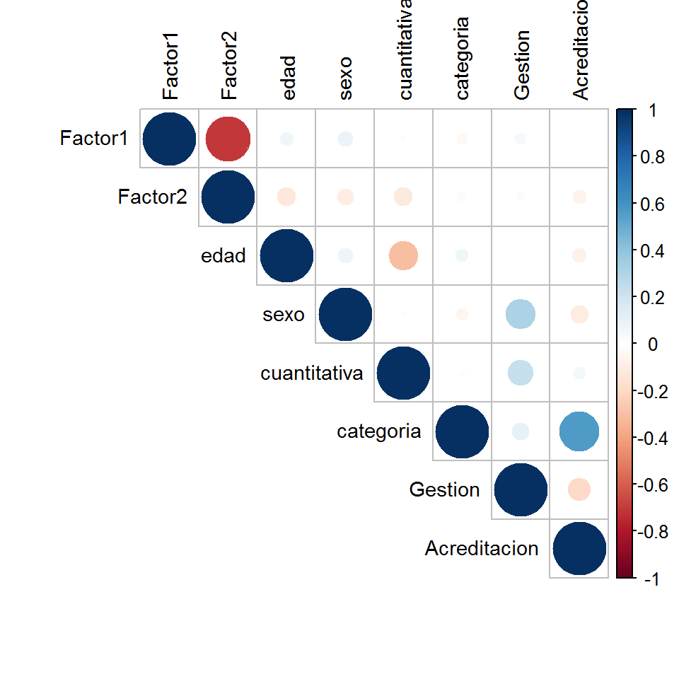

```r
corrplot(correlacion.logit, type = "upper", order = "original",
         tl.col = "black", tl.cex = 0.9)
```

Convertimos la variables categóricas a factor

```r
encuesta.logit.03$Target <- as.factor(encuesta.logit.03$Target)
encuesta.logit.03$sexo <- as.factor(encuesta.logit.03$sexo)
encuesta.logit.03$cuantitativa <- as.factor(encuesta.logit.03$cuantitativa)
encuesta.logit.03$Gestion <- as.factor(encuesta.logit.03$Gestion)
encuesta.logit.03$categoria <- as.factor(encuesta.logit.03$categoria)
encuesta.logit.03$Acreditacion <- as.factor(encuesta.logit.03$Acreditacion)
```

Eliminamos la variable `Item_10`, ya que una vez teniendo la variable binaria `Target` no nos hace falta

```r
encuesta.logit.03$Item_10 <- NULL
```

Inspeccionamos los datos

```r
str(encuesta.logit.03)
```

```
## 'data.frame':    3292 obs. of  9 variables:
##  $ Factor1     : num  0.17 0.275 0.875 0.668 0.536 ...
##  $ Factor2     : num  -1.181 -0.646 0.436 -0.91 -0.117 ...
##  $ edad        : num  40 40 40 40 40 40 40 40 40 40 ...
##  $ sexo        : Factor w/ 2 levels "0","1": 2 2 2 2 2 2 2 2 2 2 ...
##  $ cuantitativa: Factor w/ 2 levels "0","1": 2 2 2 2 2 2 2 2 2 2 ...
##  $ categoria   : Factor w/ 4 levels "1","2","3","4": 2 2 2 2 2 2 2 2 2 2 ...
##  $ Gestion     : Factor w/ 2 levels "0","1": 2 2 2 2 2 2 2 2 2 2 ...
##  $ Acreditacion: Factor w/ 2 levels "0","1": 2 2 2 2 2 2 2 2 2 2 ...
##  $ Target      : Factor w/ 2 levels "0","1": 2 2 2 2 2 2 2 2 2 2 ...
```

```r
dim(encuesta.logit.03)
```

```
## [1] 3292    9
```

```r
summary(encuesta.logit.03)
```

```
##     Factor1            Factor2              edad      sexo
##  Min.   :-6.76687   Min.   :-5.49872   Min.   :32.0   0:1717
##  1st Qu.:-0.72367   1st Qu.:-0.63121   1st Qu.:41.0   1:1575
##  Median : 0.27908   Median : 0.16184   Median :45.0
##  Mean   :-0.02198   Mean   : 0.02534   Mean   :48.1
##  3rd Qu.: 0.87490   3rd Qu.: 0.67978   3rd Qu.:54.0
##  Max.   : 4.51925   Max.   : 5.31136   Max.   :83.0
##  cuantitativa categoria Gestion  Acreditacion Target
##  0:2805       1:1205    0:2397   0:2113       0: 818
##  1: 487       2:2006    1: 895   1:1179       1:2474
##               3:  25
##               4:  56
##
##
```

```r
describe(encuesta.logit.03)
```

```
##               vars    n  mean   sd median trimmed  mad   min   max range
## Factor1          1 3292 -0.02 1.35   0.28    0.10 1.01 -6.77  4.52 11.29
## Factor2          2 3292  0.03 1.28   0.16    0.07 0.95 -5.50  5.31 10.81
## edad             3 3292 48.10 9.38  45.00   47.28 8.90 32.00 83.00 51.00
## sexo*            4 3292  1.48 0.50   1.00    1.47 0.00  1.00  2.00  1.00
## cuantitativa*    5 3292  1.15 0.36   1.00    1.06 0.00  1.00  2.00  1.00
## categoria*       6 3292  1.68 0.58   2.00    1.67 0.00  1.00  4.00  3.00
## Gestion*         7 3292  1.27 0.44   1.00    1.21 0.00  1.00  2.00  1.00
## Acreditacion*    8 3292  1.36 0.48   1.00    1.32 0.00  1.00  2.00  1.00
## Target*          9 3292  1.75 0.43   2.00    1.81 0.00  1.00  2.00  1.00
##                skew kurtosis   se
## Factor1       -0.86     1.38 0.02
## Factor2       -0.40     1.53 0.02
## edad           0.68    -0.28 0.16
## sexo*          0.09    -1.99 0.01
## cuantitativa*  1.98     1.93 0.01
## categoria*     0.71     2.32 0.01
## Gestion*       1.03    -0.95 0.01
## Acreditacion*  0.59    -1.65 0.01
## Target*       -1.16    -0.65 0.01
```

## 5.1 Estimación (entrenamiento)

```r
valoracion.logit <- glm(Target ~ ., family = binomial(link = 'logit'), data = encuesta.logit.03)
stargazer(valoracion.logit, type ='text',  p.auto=FALSE)
```

```
##
## =============================================
##                       Dependent variable:
##                   ---------------------------
##                             Target
## ---------------------------------------------
## Factor1                    3.915***
##                             (0.161)
##
## Factor2                    3.636***
##                             (0.156)
##
## edad                       0.037***
##                             (0.010)
##
## sexo1                        0.040
##                             (0.154)
##
## cuantitativa1                0.019
##                             (0.205)
##
## categoria2                  -0.047
##                             (0.194)
##
## categoria3                  -0.658
##                             (1.027)
##
## categoria4                  -0.424
##                             (0.598)
##
## Gestion1                     0.002
##                             (0.186)
##
## Acreditacion1                0.165
##                             (0.189)
##
## Constant                     0.743
##                             (0.507)
##
## ---------------------------------------------
## Observations                 3,292
## Log Likelihood             -678.204
## Akaike Inf. Crit.          1,378.407
## =============================================
## Note:             *p<0.1; **p<0.05; ***p<0.01
```

Observando la salida del modelo detectamos que solo los dos factores y la edad son estadísticamente significativos. La mayoría de las características individuales de los profesores no parecieran ser relevantes a la hora de que el alumno evalúe la asignatura, mientras que los factores que engloban el desempeño de la actividad docente, la relación profesor-alumno y la edad del instructor si lo son.

## 5.2 Efectos marginales

Debido a la naturaleza no lineal del modelo, no es posible interpretar los coeficientes directamente como en el modelo lineal, dado que el efecto marginal de la variable $x_i$ sobre la variable dependiente $y$, $(E(y|x))$ deja de ser una constante $(\beta_i)$ y pasa a ser dicha constante multiplicada por un factor de escala no trivial. Desarrollamos brevemente esta situación a continuación.

En un modelo lineal la probabilidad condicionada a las características viene dada por:

$$P(y=1|\mathbf{x})=\beta_0+\beta_1 x_1+\ldots+\beta_n x_n=\mathbf{x\beta}$$
donde es una matriz de tamaño $n\times k$, y $\beta$ un vector de tamaño $k\times 1$

Mientras que en la regresión logística

$$P(y=1|\mathbf{x})=G(\beta_0+\beta_1 x_1+\ldots+\beta_n x_n)=G(\mathbf{x\beta})$$
Como se observa la combinación lineal de regresores o características $(\mathbf{x\beta})$ afecta a la variable dependiente a través la función link $G()$, que en nuestro caso es la función logística. En el caso de la regresión lineal la función link es la función identidad, de ahí que los $\beta$’s se interpreten directamente como el efecto de un cambio en $x_i$ sobre $y$

Si deseamos obtener los efectos parciales o marginales en la regresión lineal, simplemente calculamos $\frac{\partial{y}}{\partial{x_i}}=\beta_i$

Mientras que en la regresión logística
$$\frac{\partial{y}}{\partial{x_i}}=\frac{\partial{G(\mathbf{x\beta})}}{\partial{x_i}}\beta_i=g(\mathbf{x\beta})\beta_i$$
donde $G()$ es la función de distribución acumulada y $g()$ la función de densidad.

Para calcular el efecto marginal debemos conocer no solo $\beta_i$ sino $\mathbf{x\beta}$ evaluado en $g()$

No obstante como se observa en la expresión anterior el signo de $\beta$ sigue representando la dirección del efecto marginal, por lo que podremos afirmar que los dos factores y la edad poseen un efecto positivo sobre la valoración global

El cálculo de los efectos marginales plantea el problema de que $x$’s emplear en el cálculo de la expresión anterior. Debido a que nuestro modelo posee un gran número de variables categóricas, optamos por el empleo del *efecto marginal promedio* en detrimento del efecto marginal *en el promedio*, el cual implicaría sustituir los $x$ por sus valores promedios.

El efecto marginal promedio se calcula del siguiente modo

$$\frac{1}{n}\sum_{i=1}^n g(\mathbf{x_i\hat{\beta}})=\mathbf{\hat{\beta}}g(\overline{\mathbf{x\hat{\beta}}})$$
La expresión anterior no es más que la media de la combinación lineal con la estimación de $\beta$, evaluado en la función logística. En la implementación abajo mostrada queda más clara esta idea

```r
fav <- mean(dlogis(predict(valoracion.logit)))
efectos.marginales <- fav*valoracion.logit$coefficients
efectos.marginales
```

```
##   (Intercept)       Factor1       Factor2          edad         sexo1
##  4.646004e-02  2.448548e-01  2.274272e-01  2.310434e-03  2.531539e-03
## cuantitativa1    categoria2    categoria3    categoria4      Gestion1
##  1.216360e-03 -2.915398e-03 -4.116746e-02 -2.649931e-02  9.609066e-05
## Acreditacion1
##  1.034645e-02
```

```r
efectos.marginales[2]
```

```
##   Factor1
## 0.2448548
```

```r
efectos.marginales[3]
```

```
##   Factor2
## 0.2274272
```

```r
efectos.marginales[4]
```

```
##        edad
## 0.002310434
```

En lugar de calcular manualmente los efectos marginales, el paquete `mfx` a través de su función `logitmfx` nos da el logit estimado y en lugar de presentar los $\beta$’s nos muestra directamente los efectos marginales

```r
valoracion.logit.marg <- logitmfx(Target ~ ., data = encuesta.logit.03, atmean = FALSE)
valoracion.logit.marg
```

```
## Call:
## logitmfx(formula = Target ~ ., data = encuesta.logit.03, atmean = FALSE)
##
## Marginal Effects:
##                     dF/dx   Std. Err.       z     P>|z|
## Factor1        2.4485e-01  1.9233e-02 12.7311 < 2.2e-16 ***
## Factor2        2.2743e-01  1.8101e-02 12.5641 < 2.2e-16 ***
## edad           2.3104e-03  6.2993e-04  3.6678 0.0002447 ***
## sexo1          2.5308e-03  9.6491e-03  0.2623 0.7931033
## cuantitativa1  1.2146e-03  1.2780e-02  0.0950 0.9242845
## categoria2    -2.9126e-03  1.2082e-02 -0.2411 0.8094981
## categoria3    -4.3792e-02  7.2384e-02 -0.6050 0.5451807
## categoria4    -2.7561e-02  4.0380e-02 -0.6825 0.4948979
## Gestion1       9.6086e-05  1.1646e-02  0.0083 0.9934169
## Acreditacion1  1.0295e-02  1.1685e-02  0.8811 0.3782830
## ---
## Signif. codes:  0 '***' 0.001 '**' 0.01 '*' 0.05 '.' 0.1 ' ' 1
##
## dF/dx is for discrete change for the following variables:
##
## [1] "sexo1"         "cuantitativa1" "categoria2"    "categoria3"
## [5] "categoria4"    "Gestion1"      "Acreditacion1"
```

Según estos resultados, un incremento de una unidad del factor 1 (docencia) incrementa la probabilidad de obtener una valoración alta en un 24%, mientras que un alza unitaria del factor 2 (relación profesor-alumno) aumenta la probabilidad de una valoración alta en un 22%. Mientras que una variación de la edad no parece tener ningún efecto sobre dicha probabilidad.

Esto nos lleva a plantear una primera conclusión, **no existen grandes diferencias en el efecto marginal de ambos factores**

Una manera más sencilla de interpretar los coeficientes es calculando la exponencial de los mismos. Recordemos que estamos estimando la siguiente relación:

$$P(valoracion = 1 | \mathbf{x} ) = \frac{1}{1+ e^{-\mathbf{x\beta}}}$$
Escribiendo el denominador de la expresión como:

$$1+\frac{1}{e^\mathbf{x\beta}}$$
podemos escribir la probabilidad condicionada de una valoración alta como:

$$\begin{align}
P(valoracion = 1 | \mathbf{x} ) = & \frac{1}{1+\frac{1}{e^\mathbf{x\beta}}} \\
= & \frac{1}{\frac{1+e^\mathbf{x\beta}}{e^\mathbf{x\beta}}}\\
= & \frac{e^\mathbf{x\beta}}{1+e^\mathbf{x\beta}}
\end{align}$$

por lo que la probabilidad condicionada de una valoración baja sería:

$$\begin{align}
P(valoracion = 0 | \mathbf{x} ) = & 1- \frac{e^\mathbf{x\beta}}{1+e^\mathbf{x\beta}} \\
= & \frac{1}{1+e^\mathbf{x\beta}}
\end{align}$$

Con lo anterior obtenemos el ratio de probabilidades

$$\begin{align}
\frac{P(valoracion = 1 | \mathbf{x} )}{P(valoracion = 0 | \mathbf{x} )} = &
\frac{\frac{e^\mathbf{x\beta}}{1+e^\mathbf{x\beta}}}{\frac{1}{1+e^\mathbf{x\beta}}}
= & e^\mathbf{x\beta}
\end{align}$$

El exponencial de los coeficientes nos indican que tan más probable es en términos relativos obtener una valoración alta cuando varía $x_i$ en una unidad manteniendo el restos de la $x$’s constante

```r
valoracion.logit.or <- exp(coef(valoracion.logit))
stargazer(valoracion.logit, type="text", coef=list(valoracion.logit.or), p.auto=FALSE)
```

```
##
## =============================================
##                       Dependent variable:
##                   ---------------------------
##                             Target
## ---------------------------------------------
## Factor1                    50.141***
##                             (0.161)
##
## Factor2                    37.947***
##                             (0.156)
##
## edad                       1.038***
##                             (0.010)
##
## sexo1                        1.041
##                             (0.154)
##
## cuantitativa1                1.020
##                             (0.205)
##
## categoria2                   0.954
##                             (0.194)
##
## categoria3                   0.518
##                             (1.027)
##
## categoria4                   0.655
##                             (0.598)
##
## Gestion1                     1.002
##                             (0.186)
##
## Acreditacion1                1.180
##                             (0.189)
##
## Constant                     2.102
##                             (0.507)
##
## ---------------------------------------------
## Observations                 3,292
## Log Likelihood             -678.204
## Akaike Inf. Crit.          1,378.407
## =============================================
## Note:             *p<0.1; **p<0.05; ***p<0.01
```

Manteniendo el resto de variables constante, ante un incremento unitario del factor 1 (docencia), es 50,14 veces más probable tener una valoración alta. Una variación del factor 2 (relación profesor-alumno) en una unidad hace 38 veces más probable obtener una valoración alta. Mientras que la variable sexo no parece tener efecto alguno debido a que su valor es uno.

## 5.3 Diagnosis del modelo

La bondad de ajuste del modelo logit se suele realizar de diversas formas.

Mediante una medida similar al $R^2$ empleado en el modelo lineal, conocido como pseudo-$R^2$ o de MacFadden. Dicha medida se expresa del siguiente modo:

$$1-\frac{\mathcal{L}(\hat{\beta})}{\mathcal{L}_0}$$
donde $\mathcal{L}(\hat{\beta})$ es la verosimilitud del modelo estimado (sin restringir) y $\mathcal{L}_0$ es la verosimilitud del modelo solo con el intercepto

Podemos construir el pseudo-$R^2$ con parte de la información de la función `glm` el $\mathcal{L}(\hat{\beta})$ viene dado por `Residual Deviance` y $\mathcal{L}_0$ por `Null deviance`, ambos se pueden ver al final de la salida de la función `summary`

```r
1 - valoracion.logit$deviance/valoracion.logit$null.deviance
```

```
## [1] 0.6325482
```

Se obtiene un pseudo $R^2$ de 0.63, el cual es un valor relativamente alto tomando en cuenta el problema planteado.

Otra forma de evaluar el modelo es mediante un contraste de significatividad global, similar al contraste F empleado en los modelos lineales. Para esto se emplea un contraste de razón de verosimilitudes estándar del tipo

$$LR=2(\mathcal{L}(\hat{\beta})-\mathcal{L}_0)$$
el cual podemos calcular con el empleo de la librería `lmtest` y su función `lrtest`

```r
lrtest(valoracion.logit)
```

```
## Likelihood ratio test
##
## Model 1: Target ~ Factor1 + Factor2 + edad + sexo + cuantitativa + categoria +
##     Gestion + Acreditacion
## Model 2: Target ~ 1
##   #Df  LogLik  Df Chisq Pr(>Chisq)
## 1  11  -678.2
## 2   1 -1845.7 -10  2335  < 2.2e-16 ***
## ---
## Signif. codes:  0 '***' 0.001 '**' 0.01 '*' 0.05 '.' 0.1 ' ' 1
```

Se rechaza la hipótesis nula de que el modelo estimado y un modelo con solo el intercepto sean iguales, por lo que el test de significatividad conjunta del modelo apunta a que el mismo es significativo.

### 5.3.1 Matriz de confusión

Por último presentamos la matriz de confusión, la cual compara los datos predichos por el modelo con los datos reales. Las columnas muestran los datos observados mientras que las filas muestran los datos predichos por el modelo asumiendo que una probabilidad mayor a 0,5 implica una valoración alta. Luego volveremos a si escoger 0,5 como punto de corte es adecuado o no.

```r
table(encuesta.logit.03$Target)
```

```
##
##    0    1
##  818 2474
```

```r
table(predicciones = predict(valoracion.logit, newdata = encuesta.logit.03, type= 'response')>0.5)
```

```
## predicciones
## FALSE  TRUE
##   742  2550
```

```r
matriz.confusion <-  table(prediccion = predict(valoracion.logit, newdata = encuesta.logit.03, type='response')>0.5,
      observado =encuesta.logit.03$Target)
kable(matriz.confusion, format = 'html') %>%
    kable_styling(bootstrap_options = "striped", full_width = F)
```

|  | 0 | 1 |
| --- | --- | --- |
| FALSE | 639 | 103 |
| TRUE | 179 | 2371 |

Calculamos la precisión, especificidad y sensibilidad

```r
A1 = matriz.confusion[1,1] / sum(matriz.confusion[,1])
A2 = matriz.confusion[2,2] / sum(matriz.confusion[,2])
A3 <- sum(diag(matriz.confusion)) / sum(matriz.confusion)

A1
```

```
## [1] 0.7811736
```

```r
A2
```

```
## [1] 0.958367
```

```r
A3
```

```
## [1] 0.9143378
```

La precisión es del 91,4%, la tasa de acierto de las valoraciones bajas es del 78% y las altas del 95%

El tomar 0,5 como límite para determinar la probabilidad de una valoración alta es una decisión estándar pero arbitraria. Existen maneras de determinar si esta tasa es la adecuada empleando varios criterios, a continuación mostramos como varía la precisión del modelo con distintos limites.

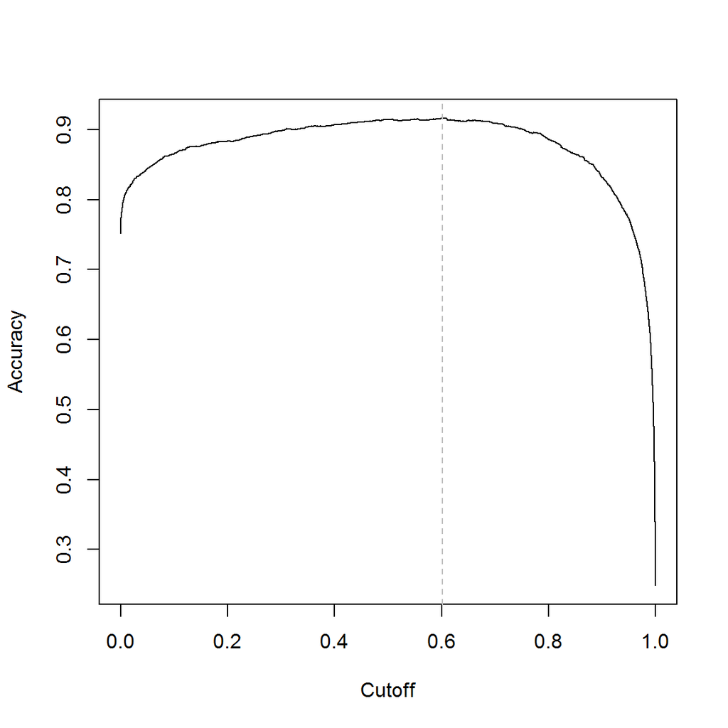

```r
prediccion <- prediction(fitted(valoracion.logit),encuesta.logit.03$Target)
precision <- performance(prediccion,'acc')
ac.val = max(unlist(precision@y.values))
th = unlist(precision@x.values)[unlist(precision@y.values) == ac.val]
plot(precision)
abline(v=th, col='grey', lty=2)
```

En la gráfica se observa que el límite que maximiza la precisión es 0,6. Repetimos la elaboración de la matriz de confusión con ese límite

```r
table(encuesta.logit.03$Target)
```

```
##
##    0    1
##  818 2474
```

```r
table(predicciones = predict(valoracion.logit, newdata = encuesta.logit.03, type= 'response')>th)
```

```
## predicciones
## FALSE  TRUE
##   840  2452
```

```r
matriz.confusion <-  table(prediccion = predict(valoracion.logit, newdata = encuesta.logit.03, type='response')>th,
                           observado =encuesta.logit.03$Target)
kable(matriz.confusion, format='html') %>%
    kable_styling(bootstrap_options = "striped", full_width = F)
```

|  | 0 | 1 |
| --- | --- | --- |
| FALSE | 691 | 149 |
| TRUE | 127 | 2325 |

Calculamos la precisión, especificidad y sensibilidad

```r
A1 = matriz.confusion[1,1] / sum(matriz.confusion[,1])
A2 = matriz.confusion[2,2] / sum(matriz.confusion[,2])
A3 <- sum(diag(matriz.confusion)) / sum(matriz.confusion)

A1
```

```
## [1] 0.8447433
```

```r
A2
```

```
## [1] 0.9397736
```

```r
A3
```

```
## [1] 0.9161604
```

La precisión aumenta levemente de 91,4% a 91,6%. Dicho incremento se explica por un aumento de la tasa de aciertos de las valoraciones bajas de 78,1% a 84.47%, mientras la tasa de aciertos de valoracionas altas se mantiene relativamente estable pasando del 95,8% al 94%

A continuación se muestra la curva ROC, en la cual se aprecia que el modelo realiza una separación bastante buena

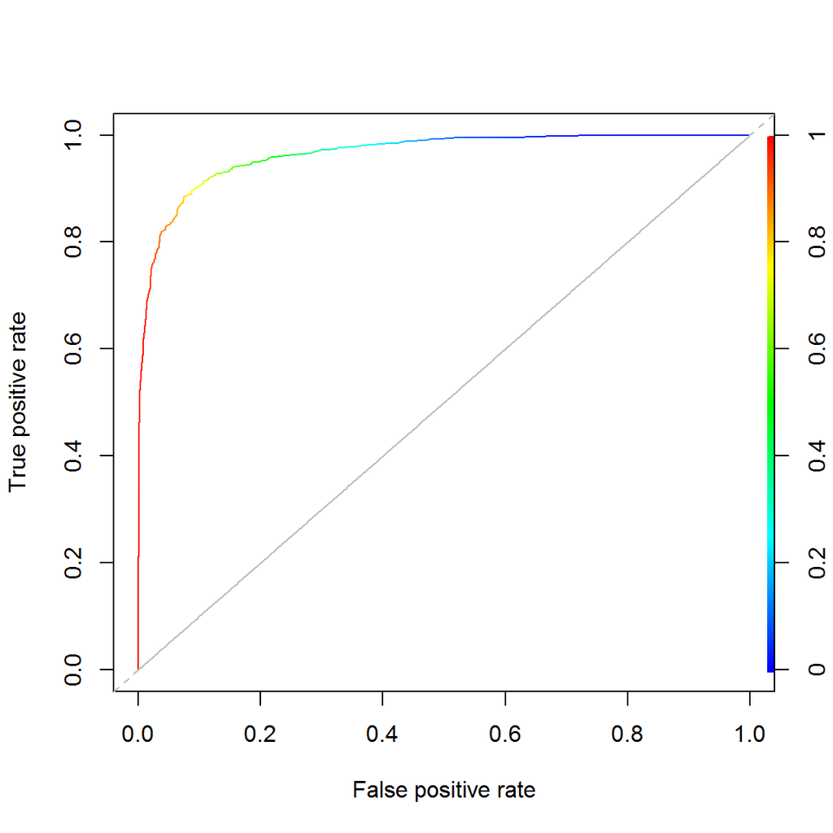

```r
plot(performance(prediccion,'tpr','fpr'),colorize=T)
abline(0,1,lty=2, col='grey')
lines(x=c(0, 1), y=c(0, 1), col="grey", lty=2)
```

Se confirma lo anterior calculando el AUC o área bajo la curva ROC

```r
auc = performance(prediccion, "auc")
auc = unlist(auc@y.values)
auc
```

```
## [1] 0.9647522
```

Se obtiene un AUC bastante cercano a uno (0,965), lo que confirma que el modelo distingue bastante bien las valoraciones altas de las bajas

Para evitar la estimación de un modelo sobreajustado, repetimos el ejercicio anterior con una muestra de entrenamiento (65%) y otra de prueba (35%).

```r
set.seed(123)
sample = sample.split(encuesta.logit.03$Target, SplitRatio = .65)
encuesta.train = subset(encuesta.logit.03, sample == TRUE)
encuesta.test  = subset(encuesta.logit.03, sample == FALSE)

valoracion.logit.01 <- glm(Target ~ ., family = binomial(link = 'logit'), data = encuesta.train)

stargazer(valoracion.logit.01, type ='text',  p.auto=FALSE)
```

```
##
## =============================================
##                       Dependent variable:
##                   ---------------------------
##                             Target
## ---------------------------------------------
## Factor1                    3.948***
##                             (0.201)
##
## Factor2                    3.717***
##                             (0.199)
##
## edad                       0.042***
##                             (0.012)
##
## sexo1                       -0.014
##                             (0.192)
##
## cuantitativa1                0.054
##                             (0.255)
##
## categoria2                  -0.012
##                             (0.240)
##
## categoria3                  -1.050
##                             (1.578)
##
## categoria4                  -0.604
##                             (0.720)
##
## Gestion1                    -0.135
##                             (0.229)
##
## Acreditacion1               -0.029
##                             (0.234)
##
## Constant                     0.566
##                             (0.628)
##
## ---------------------------------------------
## Observations                 2,140
## Log Likelihood             -443.657
## Akaike Inf. Crit.           909.314
## =============================================
## Note:             *p<0.1; **p<0.05; ***p<0.01
```

```r
logitmfx(Target ~ ., data = encuesta.train, atmean = FALSE)
```

```
## Call:
## logitmfx(formula = Target ~ ., data = encuesta.train, atmean = FALSE)
##
## Marginal Effects:
##                     dF/dx   Std. Err.       z     P>|z|
## Factor1        0.24861715  0.02420258 10.2723 < 2.2e-16 ***
## Factor2        0.23411803  0.02310429 10.1331 < 2.2e-16 ***
## edad           0.00263932  0.00080273  3.2879  0.001009 **
## sexo1         -0.00086572  0.01212640 -0.0714  0.943086
## cuantitativa1  0.00340945  0.01592279  0.2141  0.830450
## categoria2    -0.00074823  0.01509965 -0.0496  0.960479
## categoria3    -0.07287203  0.11939195 -0.6104  0.541624
## categoria4    -0.04023805  0.05059924 -0.7952  0.426479
## Gestion1      -0.00851266  0.01451659 -0.5864  0.557601
## Acreditacion1 -0.00185143  0.01478464 -0.1252  0.900344
## ---
## Signif. codes:  0 '***' 0.001 '**' 0.01 '*' 0.05 '.' 0.1 ' ' 1
##
## dF/dx is for discrete change for the following variables:
##
## [1] "sexo1"         "cuantitativa1" "categoria2"    "categoria3"
## [5] "categoria4"    "Gestion1"      "Acreditacion1"
```

```r
1 - valoracion.logit.01$deviance/valoracion.logit.01$null.deviance
```

```
## [1] 0.6303137
```

```r
lrtest(valoracion.logit.01)
```

```
## Likelihood ratio test
##
## Model 1: Target ~ Factor1 + Factor2 + edad + sexo + cuantitativa + categoria +
##     Gestion + Acreditacion
## Model 2: Target ~ 1
##   #Df   LogLik  Df  Chisq Pr(>Chisq)
## 1  11  -443.66
## 2   1 -1200.09 -10 1512.9  < 2.2e-16 ***
## ---
## Signif. codes:  0 '***' 0.001 '**' 0.01 '*' 0.05 '.' 0.1 ' ' 1
```

Observando la significatividad individual y conjunta, los efectos marginales y el pseudo $R^2$, el modelo estimado (entrenado) en la muestra train no presenta ningún cambio a resaltar, en efecto son bastantes similares

```r
table(encuesta.test$Target)
```

```
##
##   0   1
## 286 866
```

```r
table(predicciones = predict(valoracion.logit.01, newdata = encuesta.test, type= 'response')>0.5)
```

```
## predicciones
## FALSE  TRUE
##   276   876
```

```r
matriz.confusion.01 <-  table(prediccion = predict(valoracion.logit.01, newdata = encuesta.test, type='response')>0.5,
                           observado =encuesta.test$Target)
kable(matriz.confusion.01, format = 'html') %>%
    kable_styling(bootstrap_options = "striped", full_width = F)
```

|  | 0 | 1 |
| --- | --- | --- |
| FALSE | 229 | 47 |
| TRUE | 57 | 819 |

Calculamos la precisión, especificidad y sensibilidad

```r
A1 = matriz.confusion.01[1,1] / sum(matriz.confusion.01[,1])
A2 = matriz.confusion.01[2,2] / sum(matriz.confusion.01[,2])
A3 <- sum(diag(matriz.confusion.01)) / sum(matriz.confusion.01)

A1
```

```
## [1] 0.8006993
```

```r
A2
```

```
## [1] 0.9457275
```

```r
A3
```

```
## [1] 0.9097222
```

La precisión se mantiene estable en 90,97% en comparación al 91,4% obtenido con toda la muestra, empleando el límite del 0,5. Determinamos de nuevo el límite que maximiza la precisión

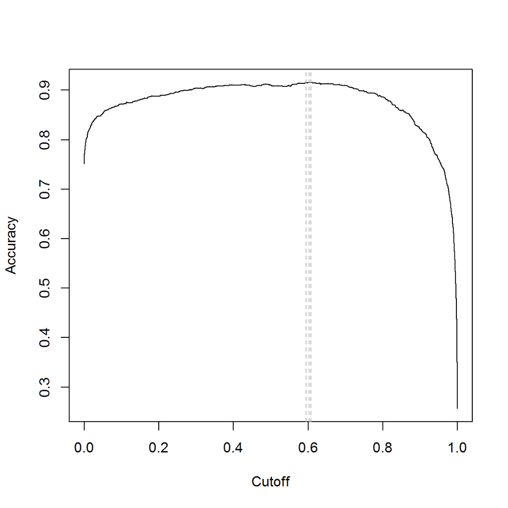

```r
prediccion.01 <- prediction(predict(valoracion.logit.01, newdata = encuesta.test, type= 'response'),
                         encuesta.test$Target)
precision.01 <- performance(prediccion.01,'acc')
ac.val.01 = max(unlist(precision.01@y.values))
th.01 = unlist(precision.01@x.values)[unlist(precision.01@y.values) == ac.val.01]
plot(precision.01)
abline(v=th.01, col='grey', lty=2)
```

En este caso tenemos 3 valores que maximizan la precisión: 0.6074202, 0.6025771 y 0.5942560. Empleamos el mayor de los valores

```r
table(encuesta.test$Target)
```

```
##
##   0   1
## 286 866
```

```r
table(predicciones = predict(valoracion.logit.01, newdata = encuesta.test, type= 'response')>unname(th.01[1]))
```

```
## predicciones
## FALSE  TRUE
##   316   836
```

```r
matriz.confusion.01 <-  table(
                              prediccion = predict(valoracion.logit.01, newdata = encuesta.test, type='response')>unname(th.01[1]),
                              observado =encuesta.test$Target)
kable(matriz.confusion.01, format = 'html')%>%
    kable_styling(bootstrap_options = "striped", full_width = F)
```

|  | 0 | 1 |
| --- | --- | --- |
| FALSE | 252 | 64 |
| TRUE | 34 | 802 |

Calculamos la precisión, especificidad y sensibilidad

```r
A1 = matriz.confusion.01[1,1] / sum(matriz.confusion.01[,1])
A2 = matriz.confusion.01[2,2] / sum(matriz.confusion.01[,2])
A3 <- sum(diag(matriz.confusion.01)) / sum(matriz.confusion.01)

A1
```

```
## [1] 0.8811189
```

```r
A2
```

```
## [1] 0.926097
```

```r
A3
```

```
## [1] 0.9149306
```

La precisión disminuye levemente de 91,6% a 91,5% comparado con el modelo estimado con la muestra completa empleando el límite que maximiza la precisión. La tasa de aciertos de las valoraciones bajas pasa de 84.47% a 88,11% y la de valoracionas altas del 94% al 92,6%

Analizamos la curva ROC del modelo en submuestras

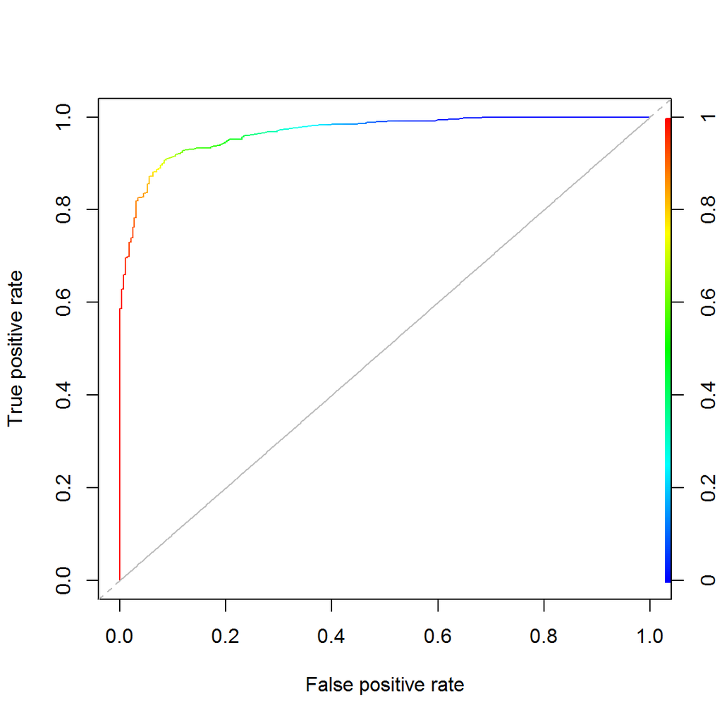

```r
plot(performance(prediccion.01,'tpr','fpr'),colorize=T)
abline(0,1,lty=2, col='grey')
lines(x=c(0, 1), y=c(0, 1), col="grey", lty=2)
```

Al igual que antes se obtiene una curva ROC que muestra una alta capacidad de clasificación del modelo. Calculamos el área bajo la curva ROC (AUC)

```r
auc.01 = performance(prediccion.01, "auc")
auc.01 = unlist(auc.01@y.values)
auc.01
```

```
## [1] 0.9663108
```

Se obtiene un valor similar al del modelo estimado con la muestra entera (0,966). El AUC confirma la buena capacidad del modelo para discriminar las valoraciones altas de las bajas.

# 6 Conclusiones

El presente trabajo tiene como objeto analizar los posibles determinantes de la valoración global de las asignaturas que imparte un centro de educación superior. Se postulan como variables explicativas los items individuales de la encuesta y características observables de los docentes.

Mediante un análisis factorial se determina que los 9 items de la encuesta pueden reducirse a 2 factores latentes, que resumen las características asociadas a la docencia y a la relación profesor-alumno. Se emplean estos factores y las características de los profesores como regresores en un logit para determinar el efecto de estos en la probabilidad de obtener una valoración alta.

La regresión logística identifica tres variables estadísticamente significativas: los dos factores y la edad del docente. Anzalizando los efectos marginales y el coeficiente de probabilidad relativos, se determina que la edad no posee ningún efecto relevante, los efectos marginales de los factores son muy similares y la probabilidad relativa del factor docencia es mayor que la correspondiente a la relación profesor-alumno.

El modelo estimado posee una buena bondad de ajuste, presentando un $R^2$ ajustado de 0.6, una precisión de 0,915 y un AUC de 0,966, exhibiendo una muy buena capacidad de separación entre valoraciones altas y bajas.

# 7 Referencias bibliográficas

Para una exposición teórica del análisis factorial se recomienda el texto de Daniel Peña [*Análisis de Datos Multivariantes*](http://www.mheducation.es/9788448136109-spain-analisis-multivariante-de-datos-group). Un muy buen desarrollo del modelo junto a su implementación en R puede encontrarse en el libro de Everitt y Hothorn [*An Introduction to Applied Multivariate Analysis with R*](http://www.springer.com/gp/book/9781441996497).

Los modelos de regresión logística o variable dependiente cualitativa en general son parte de cualquier libro introductorio de econometría y data science hoy día. Una introducción muy detallada puede encontrarse en el libro de Jeffrey M. Wooldridge [*Introducción a la econometría. Un enfoque moderno*](https://www.todostuslibros.com/libros/introduccion-a-la-econometria-4a-edicion_978-970-830-059-9). Un texto con una exposición algo más breve y avanzada, pero con ejemplos en R es el de Kleiber y Zeileis [*Applied Econometrics with R*](http://www.springer.com/gp/book/9780387773162). Para una perspectiva más de data science una buena opción es [*Practical Data Science with R*](https://www.manning.com/books/practical-data-science-with-r) de Zumel y Mount.